# Feature Selection : Evaluating Model-Independent Feature Importance for Predictors with Numeric Responses

[John Pauline Pineda](https://github.com/JohnPaulinePineda)

December 14, 2022

# **1. Table of Contents**

This project explores different model-independent feature importance metrics for predictors with numeric responses using various helpful packages in **R**. Metrics applied in the analysis to evaluate feature importance for numeric predictors included the **Locally Weighted Scatterplot Smoothing Pseudo-R-Squared**, **Pearson’s Correlation Coefficient**, **Spearman’s Rank Correlation Coefficient**, **Maximal Information Coefficient** and **Relief Values**, while that for factor predictors included the **Volcano Plot Using T-Test**. All results were consolidated in a **Summary** presented at the end of the document.  
Model-independent feature importance determines the degree of relationship, usefulness and contribution of the independent variables (features) with respect to the dependent variables (target responses), outside the context of the particular model structure being applied. Analyzing the importance metrics of features allow the discovery and inclusion of only relevant features, reducing the number of meaningful variables in the model thereby providing more targeted insights into the data, speeding up the processing time, boosting its predictive performance and improving the interpretability of the results. The algorithms applied in this study (mostly contained in the **caret** package, **stats** package, **minerva** package and **CORElearn** packages) attempt to assign scores to input features based on their relevance at discriminating or predicting the target variable.

## 1.1 Sample Data

The **Solubility** dataset from the **AppliedPredictiveModeling** package was used for this illustrated example.  
Preliminary dataset assessment:  
**[A]** 1267 rows (observations)  
**[A.1]** Train Set = 951 observations  
**[A.2]** Test Set = 316 observations  
**[B]** 229 columns (variables)  
**[B.1]** 1/229 response = Log_Solubility variable (numeric)  
**[B.2]** 228/229 predictors = All remaining variables (208/228 factor + 20/228 numeric)

**Code Chunk | Output**

```r
##################################
# Loading R libraries
##################################
library(AppliedPredictiveModeling)
library(caret)
library(rpart)
library(lattice)
library(dplyr)
library(tidyr)
library(moments)
library(skimr)
library(RANN)
library(pls)
library(corrplot)
library(tidyverse)
library(lares)
library(DMwR2)
library(gridExtra)
library(rattle)
library(rpart.plot)
library(RColorBrewer)
library(stats)
library(nnet)
library(elasticnet)
library(earth)
library(party)
library(kernlab)
library(randomForest)
library(Cubist)
library(minerva)
library(CORElearn)

##################################
# Loading source and
# formulating the train set
##################################
data(solubility)
Solubility_Train <- as.data.frame(cbind(solTrainY,solTrainX))
Solubility_Test  <- as.data.frame(cbind(solTestY,solTestX))

##################################
# Performing a general exploration of the train set
##################################
dim(Solubility_Train)
```

```
## [1] 951 229
```

```r
str(Solubility_Train)
```

```
## 'data.frame':    951 obs. of  229 variables:
##  $ solTrainY        : num  -3.97 -3.98 -3.99 -4 -4.06 -4.08 -4.08 -4.1 -4.1 -4.11 ...
##  $ FP001            : int  0 0 1 0 0 1 0 1 1 1 ...
##  $ FP002            : int  1 1 1 0 0 0 1 0 0 1 ...
##  $ FP003            : int  0 0 1 1 1 1 0 1 1 1 ...
##  $ FP004            : int  0 1 1 0 1 1 1 1 1 1 ...
##  $ FP005            : int  1 1 1 0 1 0 1 0 0 1 ...
##  $ FP006            : int  0 1 0 0 1 0 0 0 1 1 ...
##  $ FP007            : int  0 1 0 1 0 0 0 1 1 1 ...
##  $ FP008            : int  1 1 1 0 0 0 1 0 0 0 ...
##  $ FP009            : int  0 0 0 0 1 1 1 0 1 0 ...
##  $ FP010            : int  0 0 1 0 0 0 0 0 0 0 ...
##  $ FP011            : int  0 1 0 0 0 0 0 0 1 0 ...
##  $ FP012            : int  0 0 0 0 0 1 0 1 0 0 ...
##  $ FP013            : int  0 0 0 0 1 0 1 0 0 0 ...
```

[output cut: 86 more lines]

```r
summary(Solubility_Train)
```

```
##    solTrainY           FP001            FP002            FP003
##  Min.   :-11.620   Min.   :0.0000   Min.   :0.0000   Min.   :0.0000
##  1st Qu.: -3.955   1st Qu.:0.0000   1st Qu.:0.0000   1st Qu.:0.0000
##  Median : -2.510   Median :0.0000   Median :1.0000   Median :0.0000
##  Mean   : -2.719   Mean   :0.4932   Mean   :0.5394   Mean   :0.4364
##  3rd Qu.: -1.360   3rd Qu.:1.0000   3rd Qu.:1.0000   3rd Qu.:1.0000
##  Max.   :  1.580   Max.   :1.0000   Max.   :1.0000   Max.   :1.0000
##      FP004            FP005            FP006            FP007
##  Min.   :0.0000   Min.   :0.0000   Min.   :0.0000   Min.   :0.0000
##  1st Qu.:0.0000   1st Qu.:0.0000   1st Qu.:0.0000   1st Qu.:0.0000
##  Median :1.0000   Median :1.0000   Median :0.0000   Median :0.0000
##  Mean   :0.5846   Mean   :0.5794   Mean   :0.4006   Mean   :0.3638
##  3rd Qu.:1.0000   3rd Qu.:1.0000   3rd Qu.:1.0000   3rd Qu.:1.0000
##  Max.   :1.0000   Max.   :1.0000   Max.   :1.0000   Max.   :1.0000
##      FP008           FP009            FP010            FP011
##  Min.   :0.000   Min.   :0.0000   Min.   :0.0000   Min.   :0.0000
##  1st Qu.:0.000   1st Qu.:0.0000   1st Qu.:0.0000   1st Qu.:0.0000
##  Median :0.000   Median :0.0000   Median :0.0000   Median :0.0000
##  Mean   :0.326   Mean   :0.2797   Mean   :0.1788   Mean   :0.2145
##  3rd Qu.:1.000   3rd Qu.:1.0000   3rd Qu.:0.0000   3rd Qu.:0.0000
##  Max.   :1.000   Max.   :1.0000   Max.   :1.0000   Max.   :1.0000
##      FP012            FP013            FP014            FP015
##  Min.   :0.0000   Min.   :0.0000   Min.   :0.0000   Min.   :0.0000
##  1st Qu.:0.0000   1st Qu.:0.0000   1st Qu.:0.0000   1st Qu.:1.0000
##  Median :0.0000   Median :0.0000   Median :0.0000   Median :1.0000
##  Mean   :0.1767   Mean   :0.1661   Mean   :0.1609   Mean   :0.8601
##  3rd Qu.:0.0000   3rd Qu.:0.0000   3rd Qu.:0.0000   3rd Qu.:1.0000
##  Max.   :1.0000   Max.   :1.0000   Max.   :1.0000   Max.   :1.0000
##      FP016            FP017            FP018            FP019
##  Min.   :0.0000   Min.   :0.0000   Min.   :0.0000   Min.   :0.000
##  1st Qu.:0.0000   1st Qu.:0.0000   1st Qu.:0.0000   1st Qu.:0.000
##  Median :0.0000   Median :0.0000   Median :0.0000   Median :0.000
##  Mean   :0.1462   Mean   :0.1441   Mean   :0.1314   Mean   :0.122
##  3rd Qu.:0.0000   3rd Qu.:0.0000   3rd Qu.:0.0000   3rd Qu.:0.000
##  Max.   :1.0000   Max.   :1.0000   Max.   :1.0000   Max.   :1.000
##      FP020            FP021            FP022            FP023
##  Min.   :0.0000   Min.   :0.0000   Min.   :0.0000   Min.   :0.000
##  1st Qu.:0.0000   1st Qu.:0.0000   1st Qu.:0.0000   1st Qu.:0.000
##  Median :0.0000   Median :0.0000   Median :0.0000   Median :0.000
##  Mean   :0.1199   Mean   :0.1209   Mean   :0.1041   Mean   :0.123
```

[output cut: 351 more lines]

```
##  Max.   :6.0000   Max.   :13.000   Max.   :4.000   Max.   :10.0000
##    NumHalogen         NumRings     HydrophilicFactor   SurfaceArea1
##  Min.   : 0.0000   Min.   :0.000   Min.   :-0.98500   Min.   :  0.00
##  1st Qu.: 0.0000   1st Qu.:0.000   1st Qu.:-0.76300   1st Qu.:  9.23
##  Median : 0.0000   Median :1.000   Median :-0.31400   Median : 29.10
##  Mean   : 0.6982   Mean   :1.402   Mean   :-0.02059   Mean   : 36.46
##  3rd Qu.: 1.0000   3rd Qu.:2.000   3rd Qu.: 0.31300   3rd Qu.: 53.28
##  Max.   :10.0000   Max.   :7.000   Max.   :13.48300   Max.   :331.94
##   SurfaceArea2
##  Min.   :  0.00
##  1st Qu.: 10.63
##  Median : 33.12
##  Mean   : 40.23
##  3rd Qu.: 60.66
##  Max.   :331.94
```

```r
##################################
# Performing a general exploration of the test set
##################################
dim(Solubility_Test)
```

```
## [1] 316 229
```

```r
str(Solubility_Test)
```

```
## 'data.frame':    316 obs. of  229 variables:
##  $ solTestY         : num  0.93 0.85 0.81 0.74 0.61 0.58 0.57 0.56 0.52 0.45 ...
##  $ FP001            : int  1 1 0 0 1 1 1 0 1 0 ...
##  $ FP002            : int  0 0 1 0 1 0 0 0 0 1 ...
##  $ FP003            : int  0 1 0 1 0 0 0 0 1 0 ...
##  $ FP004            : int  1 1 0 0 1 1 1 1 1 0 ...
##  $ FP005            : int  0 0 1 0 1 0 0 0 0 1 ...
##  $ FP006            : int  0 1 0 1 1 0 0 0 0 0 ...
##  $ FP007            : int  0 0 0 0 0 0 0 1 1 0 ...
##  $ FP008            : int  0 0 0 0 1 0 0 0 0 0 ...
##  $ FP009            : int  1 0 0 0 0 0 0 0 0 0 ...
##  $ FP010            : int  1 0 1 0 0 0 0 0 0 0 ...
##  $ FP011            : int  0 1 0 0 1 0 0 0 0 0 ...
##  $ FP012            : int  0 1 0 0 0 1 0 1 0 0 ...
##  $ FP013            : int  0 0 0 0 0 0 0 0 0 0 ...
```

[output cut: 86 more lines]

```r
summary(Solubility_Test)
```

```
##     solTestY           FP001            FP002            FP003
##  Min.   :-10.410   Min.   :0.0000   Min.   :0.0000   Min.   :0.000
##  1st Qu.: -3.953   1st Qu.:0.0000   1st Qu.:0.0000   1st Qu.:0.000
##  Median : -2.480   Median :0.0000   Median :1.0000   Median :0.000
##  Mean   : -2.797   Mean   :0.4684   Mean   :0.5854   Mean   :0.443
##  3rd Qu.: -1.373   3rd Qu.:1.0000   3rd Qu.:1.0000   3rd Qu.:1.000
##  Max.   :  1.070   Max.   :1.0000   Max.   :1.0000   Max.   :1.000
##      FP004            FP005            FP006            FP007
##  Min.   :0.0000   Min.   :0.0000   Min.   :0.0000   Min.   :0.0000
##  1st Qu.:0.0000   1st Qu.:0.0000   1st Qu.:0.0000   1st Qu.:0.0000
##  Median :1.0000   Median :1.0000   Median :0.0000   Median :0.0000
##  Mean   :0.5316   Mean   :0.6171   Mean   :0.3513   Mean   :0.3544
##  3rd Qu.:1.0000   3rd Qu.:1.0000   3rd Qu.:1.0000   3rd Qu.:1.0000
##  Max.   :1.0000   Max.   :1.0000   Max.   :1.0000   Max.   :1.0000
##      FP008            FP009            FP010           FP011
##  Min.   :0.0000   Min.   :0.0000   Min.   :0.000   Min.   :0.0000
##  1st Qu.:0.0000   1st Qu.:0.0000   1st Qu.:0.000   1st Qu.:0.0000
##  Median :0.0000   Median :0.0000   Median :0.000   Median :0.0000
##  Mean   :0.3608   Mean   :0.2627   Mean   :0.193   Mean   :0.1741
##  3rd Qu.:1.0000   3rd Qu.:1.0000   3rd Qu.:0.000   3rd Qu.:0.0000
##  Max.   :1.0000   Max.   :1.0000   Max.   :1.000   Max.   :1.0000
##      FP012            FP013            FP014            FP015
##  Min.   :0.0000   Min.   :0.0000   Min.   :0.0000   Min.   :0.0000
##  1st Qu.:0.0000   1st Qu.:0.0000   1st Qu.:0.0000   1st Qu.:1.0000
##  Median :0.0000   Median :0.0000   Median :0.0000   Median :1.0000
##  Mean   :0.1677   Mean   :0.1646   Mean   :0.1582   Mean   :0.8291
##  3rd Qu.:0.0000   3rd Qu.:0.0000   3rd Qu.:0.0000   3rd Qu.:1.0000
##  Max.   :1.0000   Max.   :1.0000   Max.   :1.0000   Max.   :1.0000
##      FP016            FP017            FP018             FP019
##  Min.   :0.0000   Min.   :0.0000   Min.   :0.00000   Min.   :0.0000
##  1st Qu.:0.0000   1st Qu.:0.0000   1st Qu.:0.00000   1st Qu.:0.0000
##  Median :0.0000   Median :0.0000   Median :0.00000   Median :0.0000
##  Mean   :0.1424   Mean   :0.1487   Mean   :0.08544   Mean   :0.1139
##  3rd Qu.:0.0000   3rd Qu.:0.0000   3rd Qu.:0.00000   3rd Qu.:0.0000
##  Max.   :1.0000   Max.   :1.0000   Max.   :1.00000   Max.   :1.0000
##      FP020            FP021            FP022            FP023
##  Min.   :0.0000   Min.   :0.0000   Min.   :0.0000   Min.   :0.00000
##  1st Qu.:0.0000   1st Qu.:0.0000   1st Qu.:0.0000   1st Qu.:0.00000
##  Median :0.0000   Median :0.0000   Median :0.0000   Median :0.00000
##  Mean   :0.1076   Mean   :0.1076   Mean   :0.1171   Mean   :0.08544
```

[output cut: 344 more lines]

```
##  Max.   :27.000   Max.   :40.0   Max.   :24.000   Max.   :6.0000
##    NumOxygen       NumSulfer       NumChlorine      NumHalogen
##  Min.   :0.000   Min.   :0.0000   Min.   :0.000   Min.   :0.0000
##  1st Qu.:0.000   1st Qu.:0.0000   1st Qu.:0.000   1st Qu.:0.0000
##  Median :1.000   Median :0.0000   Median :0.000   Median :0.0000
##  Mean   :1.389   Mean   :0.1013   Mean   :0.557   Mean   :0.7089
##  3rd Qu.:2.000   3rd Qu.:0.0000   3rd Qu.:0.000   3rd Qu.:1.0000
##  Max.   :9.000   Max.   :3.0000   Max.   :9.000   Max.   :9.0000
##     NumRings     HydrophilicFactor  SurfaceArea1     SurfaceArea2
##  Min.   :0.000   Min.   :-0.9860   Min.   :  0.00   Min.   :  0.00
##  1st Qu.:1.000   1st Qu.:-0.7670   1st Qu.:  9.23   1st Qu.:  9.23
##  Median :1.000   Median :-0.3970   Median : 26.30   Median : 26.30
##  Mean   :1.399   Mean   :-0.1022   Mean   : 32.76   Mean   : 35.04
##  3rd Qu.:2.000   3rd Qu.: 0.2140   3rd Qu.: 49.55   3rd Qu.: 52.32
##  Max.   :6.000   Max.   : 5.0000   Max.   :201.85   Max.   :201.85
```

```r
##################################
# Formulating a data type assessment summary
##################################
PDA <- Solubility_Train
(PDA.Summary <- data.frame(
  Column.Index=c(1:length(names(PDA))),
  Column.Name= names(PDA),
  Column.Type=sapply(PDA, function(x) class(x)),
  row.names=NULL)
)
```

```
##     Column.Index       Column.Name Column.Type
## 1              1         solTrainY     numeric
## 2              2             FP001     integer
## 3              3             FP002     integer
## 4              4             FP003     integer
## 5              5             FP004     integer
## 6              6             FP005     integer
## 7              7             FP006     integer
## 8              8             FP007     integer
## 9              9             FP008     integer
## 10            10             FP009     integer
## 11            11             FP010     integer
## 12            12             FP011     integer
## 13            13             FP012     integer
## 14            14             FP013     integer
```

[output cut: 215 more lines]

## 1.2 Data Quality Assessment

**[A]** No missing observations noted for any variable.  
**[B]** Low variance observed for 127 variables with First.Second.Mode.Ratio>5.  
**[B.1]-[B.33]** FP013 to FP045 variables (factor)  
**[B.34]-[B.45]** FP048 to FP059 variables (factor)  
**[B.46]** FP114 variable (factor)  
**[B.47]-[B.50]** FP119 to FP122 variable (factor)  
**[B.51]-[B.88]** FP124 to FP161 variables (factor)  
**[B.89]-[B.118]** FP172 to FP201 variables (factor)  
**[B.119]-[B.124]** FP203 to FP208 variables (factor)  
**[B.125]** NumSulfer variable (numeric)  
**[B.126]** NumChlorine variable (numeric)  
**[B.127]** NumHalogen variable (numeric)  
**[C]** Low variance observed for 4 variables with Unique.Count.Ratio<0.01.  
**[C.1]** NumDblBonds variable (numeric)  
**[C.2]** NumNitrogen variable (numeric)  
**[C.3]** NumSulfer variable (numeric)  
**[C.4]** NumRings variable (numeric)  
**[D]** High skewness observed for 3 variables with Skewness>3 or Skewness<(-3).  
**[D.1]** NumSulfer variable (numeric)  
**[D.2]** NumChlorine variable (numeric)  
**[D.3]** HydrophilicFactor variable (numeric)

**Code Chunk | Output**

```r
##################################
# Loading dataset
##################################
DQA <- Solubility_Train

##################################
# Formulating an overall data quality assessment summary
##################################
(DQA.Summary <- data.frame(
  Column.Index=c(1:length(names(DQA))),
  Column.Name= names(DQA),
  Column.Type=sapply(DQA, function(x) class(x)),
  Row.Count=sapply(DQA, function(x) nrow(DQA)),
  NA.Count=sapply(DQA,function(x)sum(is.na(x))),
  Fill.Rate=sapply(DQA,function(x)format(round((sum(!is.na(x))/nrow(DQA)),3),nsmall=3)),
  row.names=NULL)
)
```

```
##     Column.Index       Column.Name Column.Type Row.Count NA.Count Fill.Rate
## 1              1         solTrainY     numeric       951        0     1.000
## 2              2             FP001     integer       951        0     1.000
## 3              3             FP002     integer       951        0     1.000
## 4              4             FP003     integer       951        0     1.000
## 5              5             FP004     integer       951        0     1.000
## 6              6             FP005     integer       951        0     1.000
## 7              7             FP006     integer       951        0     1.000
## 8              8             FP007     integer       951        0     1.000
## 9              9             FP008     integer       951        0     1.000
## 10            10             FP009     integer       951        0     1.000
## 11            11             FP010     integer       951        0     1.000
## 12            12             FP011     integer       951        0     1.000
## 13            13             FP012     integer       951        0     1.000
## 14            14             FP013     integer       951        0     1.000
```

[output cut: 215 more lines]

```r
##################################
# Listing all predictors
##################################
DQA.Predictors <- DQA[,!names(DQA) %in% c("solTrainY")]

##################################
# Listing all numeric predictors
##################################
DQA.Predictors.Numeric <- DQA.Predictors[,-(grep("FP", names(DQA.Predictors)))]

if (length(names(DQA.Predictors.Numeric))>0) {
    print(paste0("There are ",
               (length(names(DQA.Predictors.Numeric))),
               " numeric predictor variable(s)."))
} else {
  print("There are no numeric predictor variables.")
}
```

```
## [1] "There are 20 numeric predictor variable(s)."
```

```r
##################################
# Listing all factor predictors
##################################
DQA.Predictors.Factor <-as.data.frame(lapply(DQA.Predictors[(grep("FP", names(DQA.Predictors)))],factor))

if (length(names(DQA.Predictors.Factor))>0) {
    print(paste0("There are ",
               (length(names(DQA.Predictors.Factor))),
               " factor predictor variable(s)."))
} else {
  print("There are no factor predictor variables.")
}
```

```
## [1] "There are 208 factor predictor variable(s)."
```

```r
##################################
# Formulating a data quality assessment summary for factor predictors
##################################
if (length(names(DQA.Predictors.Factor))>0) {

  ##################################
  # Formulating a function to determine the first mode
  ##################################
  FirstModes <- function(x) {
    ux <- unique(na.omit(x))
    tab <- tabulate(match(x, ux))
    ux[tab == max(tab)]
  }

  ##################################
  # Formulating a function to determine the second mode
  ##################################
  SecondModes <- function(x) {
    ux <- unique(na.omit(x))
    tab <- tabulate(match(x, ux))
    fm = ux[tab == max(tab)]
    sm = x[!(x %in% fm)]
    usm <- unique(sm)
    tabsm <- tabulate(match(sm, usm))
    ifelse(is.na(usm[tabsm == max(tabsm)])==TRUE,
           return("x"),
           return(usm[tabsm == max(tabsm)]))
  }

  (DQA.Predictors.Factor.Summary <- data.frame(
  Column.Name= names(DQA.Predictors.Factor),
  Column.Type=sapply(DQA.Predictors.Factor, function(x) class(x)),
  Unique.Count=sapply(DQA.Predictors.Factor, function(x) length(unique(x))),
  First.Mode.Value=sapply(DQA.Predictors.Factor, function(x) as.character(FirstModes(x)[1])),
  Second.Mode.Value=sapply(DQA.Predictors.Factor, function(x) as.character(SecondModes(x)[1])),
  First.Mode.Count=sapply(DQA.Predictors.Factor, function(x) sum(na.omit(x) == FirstModes(x)[1])),
  Second.Mode.Count=sapply(DQA.Predictors.Factor, function(x) sum(na.omit(x) == SecondModes(x)[1])),
  Unique.Count.Ratio=sapply(DQA.Predictors.Factor, function(x) format(round((length(unique(x))/nrow(DQA.Predictors.Factor)),3), nsmall=3)),
  First.Second.Mode.Ratio=sapply(DQA.Predictors.Factor, function(x) format(round((sum(na.omit(x) == FirstModes(x)[1])/sum(na.omit(x) == SecondModes(x)[1])),3), nsmall=3)),
  row.names=NULL)
  )

}
```

```
##     Column.Name Column.Type Unique.Count First.Mode.Value Second.Mode.Value
## 1         FP001      factor            2                0                 1
## 2         FP002      factor            2                1                 0
## 3         FP003      factor            2                0                 1
## 4         FP004      factor            2                1                 0
## 5         FP005      factor            2                1                 0
## 6         FP006      factor            2                0                 1
## 7         FP007      factor            2                0                 1
## 8         FP008      factor            2                0                 1
## 9         FP009      factor            2                0                 1
## 10        FP010      factor            2                0                 1
## 11        FP011      factor            2                0                 1
## 12        FP012      factor            2                0                 1
## 13        FP013      factor            2                0                 1
## 14        FP014      factor            2                0                 1
```

[output cut: 612 more lines]

```r
##################################
# Formulating a data quality assessment summary for numeric predictors
##################################
if (length(names(DQA.Predictors.Numeric))>0) {

  ##################################
  # Formulating a function to determine the first mode
  ##################################
  FirstModes <- function(x) {
    ux <- unique(na.omit(x))
    tab <- tabulate(match(x, ux))
    ux[tab == max(tab)]
  }

  ##################################
  # Formulating a function to determine the second mode
  ##################################
  SecondModes <- function(x) {
    ux <- unique(na.omit(x))
    tab <- tabulate(match(x, ux))
    fm = ux[tab == max(tab)]
    sm = na.omit(x)[!(na.omit(x) %in% fm)]
    usm <- unique(sm)
    tabsm <- tabulate(match(sm, usm))
    ifelse(is.na(usm[tabsm == max(tabsm)])==TRUE,
           return(0.00001),
           return(usm[tabsm == max(tabsm)]))
  }

  (DQA.Predictors.Numeric.Summary <- data.frame(
  Column.Name= names(DQA.Predictors.Numeric),
  Column.Type=sapply(DQA.Predictors.Numeric, function(x) class(x)),
  Unique.Count=sapply(DQA.Predictors.Numeric, function(x) length(unique(x))),
  Unique.Count.Ratio=sapply(DQA.Predictors.Numeric, function(x) format(round((length(unique(x))/nrow(DQA.Predictors.Numeric)),3), nsmall=3)),
  First.Mode.Value=sapply(DQA.Predictors.Numeric, function(x) format(round((FirstModes(x)[1]),3),nsmall=3)),
  Second.Mode.Value=sapply(DQA.Predictors.Numeric, function(x) format(round((SecondModes(x)[1]),3),nsmall=3)),
  First.Mode.Count=sapply(DQA.Predictors.Numeric, function(x) sum(na.omit(x) == FirstModes(x)[1])),
  Second.Mode.Count=sapply(DQA.Predictors.Numeric, function(x) sum(na.omit(x) == SecondModes(x)[1])),
  First.Second.Mode.Ratio=sapply(DQA.Predictors.Numeric, function(x) format(round((sum(na.omit(x) == FirstModes(x)[1])/sum(na.omit(x) == SecondModes(x)[1])),3), nsmall=3)),
  Minimum=sapply(DQA.Predictors.Numeric, function(x) format(round(min(x,na.rm = TRUE),3), nsmall=3)),
  Mean=sapply(DQA.Predictors.Numeric, function(x) format(round(mean(x,na.rm = TRUE),3), nsmall=3)),
  Median=sapply(DQA.Predictors.Numeric, function(x) format(round(median(x,na.rm = TRUE),3), nsmall=3)),
  Maximum=sapply(DQA.Predictors.Numeric, function(x) format(round(max(x,na.rm = TRUE),3), nsmall=3)),
  Skewness=sapply(DQA.Predictors.Numeric, function(x) format(round(skewness(x,na.rm = TRUE),3), nsmall=3)),
  Kurtosis=sapply(DQA.Predictors.Numeric, function(x) format(round(kurtosis(x,na.rm = TRUE),3), nsmall=3)),
  Percentile25th=sapply(DQA.Predictors.Numeric, function(x) format(round(quantile(x,probs=0.25,na.rm = TRUE),3), nsmall=3)),
  Percentile75th=sapply(DQA.Predictors.Numeric, function(x) format(round(quantile(x,probs=0.75,na.rm = TRUE),3), nsmall=3)),
  row.names=NULL)
  )

}
```

```
##          Column.Name Column.Type Unique.Count Unique.Count.Ratio
## 1          MolWeight     numeric          646              0.679
## 2           NumAtoms     integer           66              0.069
## 3       NumNonHAtoms     integer           36              0.038
## 4           NumBonds     integer           72              0.076
## 5       NumNonHBonds     integer           39              0.041
## 6       NumMultBonds     integer           25              0.026
## 7        NumRotBonds     integer           15              0.016
## 8        NumDblBonds     integer            8              0.008
## 9   NumAromaticBonds     integer           16              0.017
## 10       NumHydrogen     integer           41              0.043
## 11         NumCarbon     integer           28              0.029
## 12       NumNitrogen     integer            7              0.007
## 13         NumOxygen     integer           11              0.012
## 14         NumSulfer     integer            5              0.005
```

[output cut: 69 more lines]

```r
##################################
# Identifying potential data quality issues
##################################

##################################
# Checking for missing observations
##################################
if ((nrow(DQA.Summary[DQA.Summary$NA.Count>0,]))>0){
  print(paste0("Missing observations noted for ",
               (nrow(DQA.Summary[DQA.Summary$NA.Count>0,])),
               " variable(s) with NA.Count>0 and Fill.Rate<1.0."))
  DQA.Summary[DQA.Summary$NA.Count>0,]
} else {
  print("No missing observations noted.")
}
```

```
## [1] "No missing observations noted."
```

```r
##################################
# Checking for zero or near-zero variance predictors
##################################
if (length(names(DQA.Predictors.Factor))==0) {
  print("No factor predictors noted.")
} else if (nrow(DQA.Predictors.Factor.Summary[as.numeric(as.character(DQA.Predictors.Factor.Summary$First.Second.Mode.Ratio))>5,])>0){
  print(paste0("Low variance observed for ",
               (nrow(DQA.Predictors.Factor.Summary[as.numeric(as.character(DQA.Predictors.Factor.Summary$First.Second.Mode.Ratio))>5,])),
               " factor variable(s) with First.Second.Mode.Ratio>5."))
  DQA.Predictors.Factor.Summary[as.numeric(as.character(DQA.Predictors.Factor.Summary$First.Second.Mode.Ratio))>5,]
} else {
  print("No low variance factor predictors due to high first-second mode ratio noted.")
}
```

```
## [1] "Low variance observed for 124 factor variable(s) with First.Second.Mode.Ratio>5."
```

```
##     Column.Name Column.Type Unique.Count First.Mode.Value Second.Mode.Value
## 13        FP013      factor            2                0                 1
## 14        FP014      factor            2                0                 1
## 15        FP015      factor            2                1                 0
## 16        FP016      factor            2                0                 1
## 17        FP017      factor            2                0                 1
## 18        FP018      factor            2                0                 1
## 19        FP019      factor            2                0                 1
## 20        FP020      factor            2                0                 1
## 21        FP021      factor            2                0                 1
## 22        FP022      factor            2                0                 1
## 23        FP023      factor            2                0                 1
## 24        FP024      factor            2                0                 1
## 25        FP025      factor            2                0                 1
## 26        FP026      factor            2                0                 1
```

[output cut: 360 more lines]

```r
if (length(names(DQA.Predictors.Numeric))==0) {
  print("No numeric predictors noted.")
} else if (nrow(DQA.Predictors.Numeric.Summary[as.numeric(as.character(DQA.Predictors.Numeric.Summary$First.Second.Mode.Ratio))>5,])>0){
  print(paste0("Low variance observed for ",
               (nrow(DQA.Predictors.Numeric.Summary[as.numeric(as.character(DQA.Predictors.Numeric.Summary$First.Second.Mode.Ratio))>5,])),
               " numeric variable(s) with First.Second.Mode.Ratio>5."))
  DQA.Predictors.Numeric.Summary[as.numeric(as.character(DQA.Predictors.Numeric.Summary$First.Second.Mode.Ratio))>5,]
} else {
  print("No low variance numeric predictors due to high first-second mode ratio noted.")
}
```

```
## [1] "Low variance observed for 3 numeric variable(s) with First.Second.Mode.Ratio>5."
```

```
##    Column.Name Column.Type Unique.Count Unique.Count.Ratio First.Mode.Value
## 14   NumSulfer     integer            5              0.005            0.000
## 15 NumChlorine     integer           11              0.012            0.000
## 16  NumHalogen     integer           11              0.012            0.000
##    Second.Mode.Value First.Mode.Count Second.Mode.Count First.Second.Mode.Ratio
## 14             1.000              830                96                   8.646
## 15             1.000              750                81                   9.259
## 16             1.000              685               107                   6.402
##    Minimum  Mean Median Maximum Skewness Kurtosis Percentile25th Percentile75th
## 14   0.000 0.164  0.000   4.000    3.842   21.526          0.000          0.000
## 15   0.000 0.556  0.000  10.000    3.178   13.780          0.000          0.000
## 16   0.000 0.698  0.000  10.000    2.691   10.808          0.000          1.000
```

```r
if (length(names(DQA.Predictors.Numeric))==0) {
  print("No numeric predictors noted.")
} else if (nrow(DQA.Predictors.Numeric.Summary[as.numeric(as.character(DQA.Predictors.Numeric.Summary$Unique.Count.Ratio))<0.01,])>0){
  print(paste0("Low variance observed for ",
               (nrow(DQA.Predictors.Numeric.Summary[as.numeric(as.character(DQA.Predictors.Numeric.Summary$Unique.Count.Ratio))<0.01,])),
               " numeric variable(s) with Unique.Count.Ratio<0.01."))
  DQA.Predictors.Numeric.Summary[as.numeric(as.character(DQA.Predictors.Numeric.Summary$Unique.Count.Ratio))<0.01,]
} else {
  print("No low variance numeric predictors due to low unique count ratio noted.")
}
```

```
## [1] "Low variance observed for 4 numeric variable(s) with Unique.Count.Ratio<0.01."
```

```
##    Column.Name Column.Type Unique.Count Unique.Count.Ratio First.Mode.Value
## 8  NumDblBonds     integer            8              0.008            0.000
## 12 NumNitrogen     integer            7              0.007            0.000
## 14   NumSulfer     integer            5              0.005            0.000
## 17    NumRings     integer            8              0.008            1.000
##    Second.Mode.Value First.Mode.Count Second.Mode.Count First.Second.Mode.Ratio
## 8              1.000              427               268                   1.593
## 12             1.000              546               191                   2.859
## 14             1.000              830                96                   8.646
## 17             0.000              323               260                   1.242
##    Minimum  Mean Median Maximum Skewness Kurtosis Percentile25th Percentile75th
## 8    0.000 1.006  1.000   7.000    1.360    4.760          0.000          2.000
## 12   0.000 0.813  0.000   6.000    1.554    4.831          0.000          1.000
## 14   0.000 0.164  0.000   4.000    3.842   21.526          0.000          0.000
## 17   0.000 1.402  1.000   7.000    1.034    3.875          0.000          2.000
```

```r
##################################
# Checking for skewed predictors
##################################
if (length(names(DQA.Predictors.Numeric))==0) {
  print("No numeric predictors noted.")
} else if (nrow(DQA.Predictors.Numeric.Summary[as.numeric(as.character(DQA.Predictors.Numeric.Summary$Skewness))>3 |
                                               as.numeric(as.character(DQA.Predictors.Numeric.Summary$Skewness))<(-3),])>0){
  print(paste0("High skewness observed for ",
  (nrow(DQA.Predictors.Numeric.Summary[as.numeric(as.character(DQA.Predictors.Numeric.Summary$Skewness))>3 |
                                               as.numeric(as.character(DQA.Predictors.Numeric.Summary$Skewness))<(-3),])),
  " numeric variable(s) with Skewness>3 or Skewness<(-3)."))
  DQA.Predictors.Numeric.Summary[as.numeric(as.character(DQA.Predictors.Numeric.Summary$Skewness))>3 |
                                 as.numeric(as.character(DQA.Predictors.Numeric.Summary$Skewness))<(-3),]
} else {
  print("No skewed numeric predictors noted.")
}
```

```
## [1] "High skewness observed for 3 numeric variable(s) with Skewness>3 or Skewness<(-3)."
```

```
##          Column.Name Column.Type Unique.Count Unique.Count.Ratio
## 14         NumSulfer     integer            5              0.005
## 15       NumChlorine     integer           11              0.012
## 18 HydrophilicFactor     numeric          369              0.388
##    First.Mode.Value Second.Mode.Value First.Mode.Count Second.Mode.Count
## 14            0.000             1.000              830                96
## 15            0.000             1.000              750                81
## 18           -0.828            -0.158               21                20
##    First.Second.Mode.Ratio Minimum   Mean Median Maximum Skewness Kurtosis
## 14                   8.646   0.000  0.164  0.000   4.000    3.842   21.526
## 15                   9.259   0.000  0.556  0.000  10.000    3.178   13.780
## 18                   1.050  -0.985 -0.021 -0.314  13.483    3.404   27.504
##    Percentile25th Percentile75th
## 14          0.000          0.000
## 15          0.000          0.000
## 18         -0.763          0.313
```

## 1.3 Data Preprocessing

### 1.3.1 Outlier

**[A]** Outliers noted for 20 variables with the numeric data visualized through a boxplot including observations classified as suspected outliers using the IQR criterion. The IQR criterion means that all observations above the (75th percentile + 1.5 x IQR) or below the (25th percentile - 1.5 x IQR) are suspected outliers, where IQR is the difference between the third quartile (75th percentile) and first quartile (25th percentile). Outlier treatment for numerical stability remains optional depending on potential model requirements for the subsequent steps.  
**[A.1]** MolWeight variable (8 outliers detected)  
**[A.2]** NumAtoms variable (44 outliers detected)  
**[A.3]** NumNonHAtoms variable (15 outliers detected)  
**[A.4]** NumBonds variable (51 outliers detected)  
**[A.5]** NumNonHBonds variable (18 outliers detected)  
**[A.6]** NumMultBonds variable (6 outliers detected)  
**[A.7]** NumRotBonds variable (23 outliers detected)  
**[A.8]** NumDblBonds variable (3 outliers detected)  
**[A.9]** NumAromaticBonds variable (35 outliers detected)  
**[A.10]** NumHydrogen variable (32 outliers detected)  
**[A.11]** NumCarbon variable (35 outliers detected)  
**[A.12]** NumNitrogen variable (91 outliers detected)  
**[A.13]** NumOxygen variable (36 outliers detected)  
**[A.14]** NumSulfer variable (121 outliers detected)  
**[A.15]** NumChlorine variable (201 outliers detected)  
**[A.16]** NumHalogen variable (99 outliers detected)  
**[A.17]** NumRings variable (4 outliers detected)  
**[A.18]** HydrophilicFactor variable (53 outliers detected)  
**[A.19]** SurfaceArea1 variable (19 outliers detected)  
**[A.20]** SurfaceArea2 variable (12 outliers detected)

**Code Chunk | Output**

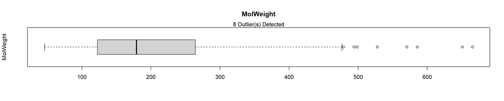

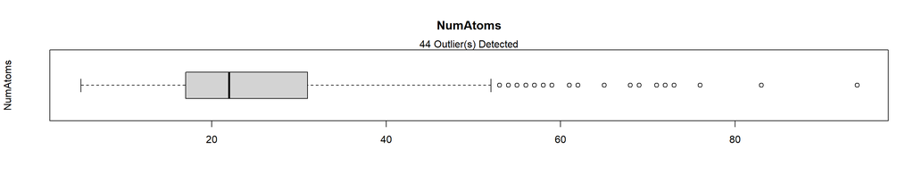

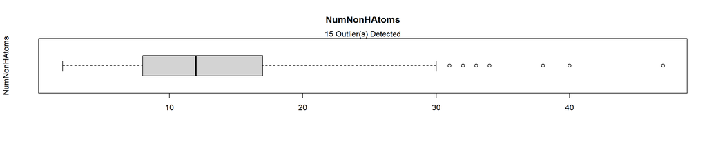

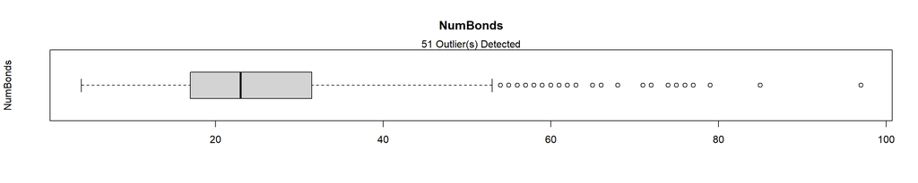

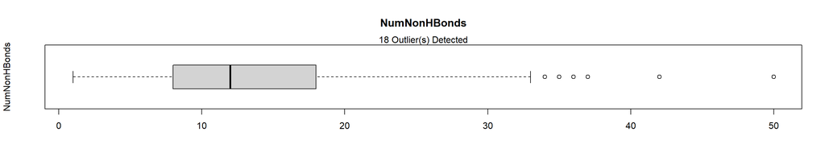

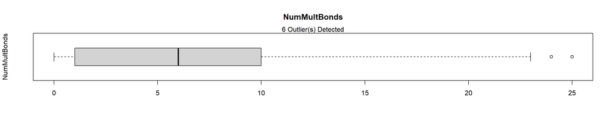

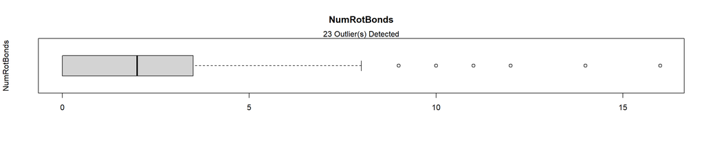

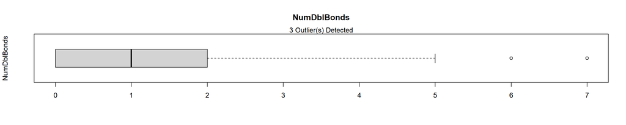

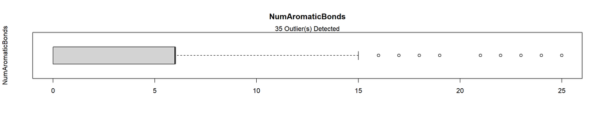

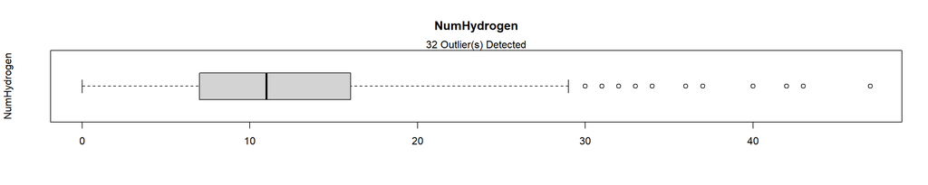

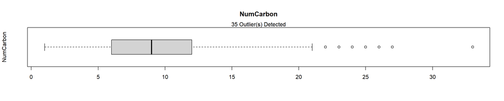

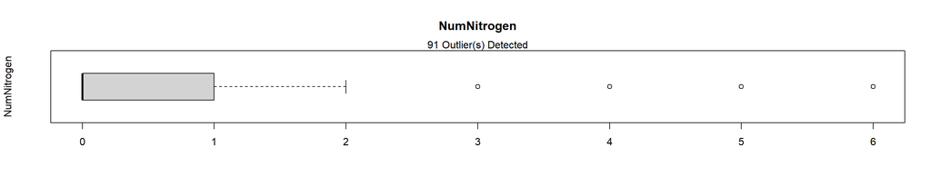

[8 more figures not shown]

```r
##################################
# Loading dataset
##################################
DPA <- Solubility_Train

##################################
# Listing all predictors
##################################
DPA.Predictors <- DPA[,!names(DPA) %in% c("solTrainY")]

##################################
# Listing all numeric predictors
##################################
DPA.Predictors.Numeric <- DPA.Predictors[,-(grep("FP", names(DPA.Predictors)))]

##################################
# Identifying outliers for the numeric predictors
##################################
OutlierCountList <- c()

for (i in 1:ncol(DPA.Predictors.Numeric)) {
  Outliers <- boxplot.stats(DPA.Predictors.Numeric[,i])$out
  OutlierCount <- length(Outliers)
  OutlierCountList <- append(OutlierCountList,OutlierCount)
  OutlierIndices <- which(DPA.Predictors.Numeric[,i] %in% c(Outliers))
  boxplot(DPA.Predictors.Numeric[,i],
          ylab = names(DPA.Predictors.Numeric)[i],
          main = names(DPA.Predictors.Numeric)[i],
          horizontal=TRUE)
  mtext(paste0(OutlierCount, " Outlier(s) Detected"))
}
```

```r
OutlierCountSummary <- as.data.frame(cbind(names(DPA.Predictors.Numeric),(OutlierCountList)))
names(OutlierCountSummary) <- c("NumericPredictors","OutlierCount")
OutlierCountSummary$OutlierCount <- as.numeric(as.character(OutlierCountSummary$OutlierCount))
NumericPredictorWithOutlierCount <- nrow(OutlierCountSummary[OutlierCountSummary$OutlierCount>0,])
print(paste0(NumericPredictorWithOutlierCount, " numeric variable(s) were noted with outlier(s)." ))
```

```
## [1] "20 numeric variable(s) were noted with outlier(s)."
```

```r
##################################
# Gathering descriptive statistics
##################################
(DPA_Skimmed <- skim(DPA.Predictors.Numeric))
```

Data summary

| Name | DPA.Predictors.Numeric |
| --- | --- |
| Number of rows | 951 |
| Number of columns | 20 |
| _______________________ |  |
| Column type frequency: |  |
| numeric | 20 |
| ________________________ |  |
| Group variables | None |

**Variable type: numeric**

| skim_variable | n_missing | complete_rate | mean | sd | p0 | p25 | p50 | p75 | p100 | hist |
| --- | --- | --- | --- | --- | --- | --- | --- | --- | --- | --- |
| MolWeight | 0 | 1 | 201.65 | 97.91 | 46.09 | 122.60 | 179.23 | 264.34 | 665.81 | ▇▆▂▁▁ |
| NumAtoms | 0 | 1 | 25.51 | 12.61 | 5.00 | 17.00 | 22.00 | 31.00 | 94.00 | ▇▆▂▁▁ |
| NumNonHAtoms | 0 | 1 | 13.16 | 6.50 | 2.00 | 8.00 | 12.00 | 17.00 | 47.00 | ▇▆▂▁▁ |
| NumBonds | 0 | 1 | 25.91 | 13.48 | 4.00 | 17.00 | 23.00 | 31.50 | 97.00 | ▇▇▂▁▁ |
| NumNonHBonds | 0 | 1 | 13.56 | 7.57 | 1.00 | 8.00 | 12.00 | 18.00 | 50.00 | ▇▇▂▁▁ |
| NumMultBonds | 0 | 1 | 6.15 | 5.17 | 0.00 | 1.00 | 6.00 | 10.00 | 25.00 | ▇▆▃▁▁ |
| NumRotBonds | 0 | 1 | 2.25 | 2.41 | 0.00 | 0.00 | 2.00 | 3.50 | 16.00 | ▇▂▁▁▁ |
| NumDblBonds | 0 | 1 | 1.01 | 1.21 | 0.00 | 0.00 | 1.00 | 2.00 | 7.00 | ▇▂▁▁▁ |
| NumAromaticBonds | 0 | 1 | 5.12 | 5.26 | 0.00 | 0.00 | 6.00 | 6.00 | 25.00 | ▇▆▃▁▁ |
| NumHydrogen | 0 | 1 | 12.35 | 7.32 | 0.00 | 7.00 | 11.00 | 16.00 | 47.00 | ▇▇▂▁▁ |
| NumCarbon | 0 | 1 | 9.89 | 5.29 | 1.00 | 6.00 | 9.00 | 12.00 | 33.00 | ▇▇▃▁▁ |
| NumNitrogen | 0 | 1 | 0.81 | 1.19 | 0.00 | 0.00 | 0.00 | 1.00 | 6.00 | ▇▂▁▁▁ |
| NumOxygen | 0 | 1 | 1.57 | 1.73 | 0.00 | 0.00 | 1.00 | 2.00 | 13.00 | ▇▂▁▁▁ |
| NumSulfer | 0 | 1 | 0.16 | 0.49 | 0.00 | 0.00 | 0.00 | 0.00 | 4.00 | ▇▁▁▁▁ |
| NumChlorine | 0 | 1 | 0.56 | 1.40 | 0.00 | 0.00 | 0.00 | 0.00 | 10.00 | ▇▁▁▁▁ |
| NumHalogen | 0 | 1 | 0.70 | 1.47 | 0.00 | 0.00 | 0.00 | 1.00 | 10.00 | ▇▁▁▁▁ |
| NumRings | 0 | 1 | 1.40 | 1.30 | 0.00 | 0.00 | 1.00 | 2.00 | 7.00 | ▇▃▂▁▁ |
| HydrophilicFactor | 0 | 1 | -0.02 | 1.13 | -0.98 | -0.76 | -0.31 | 0.31 | 13.48 | ▇▁▁▁▁ |
| SurfaceArea1 | 0 | 1 | 36.46 | 35.29 | 0.00 | 9.23 | 29.10 | 53.28 | 331.94 | ▇▂▁▁▁ |
| SurfaceArea2 | 0 | 1 | 40.23 | 38.12 | 0.00 | 10.63 | 33.12 | 60.66 | 331.94 | ▇▂▁▁▁ |

```r
###################################
# Verifying the data dimensions
###################################
dim(DPA.Predictors.Numeric)
```

```
## [1] 951  20
```

### 1.3.2 Zero and Near-Zero Variance

**[A]** Low variance noted for 127 variables from the previous data quality assessment using a lower threshold.  
**[B]** Low variance noted for 3 variables using a preprocessing summary from the **caret** package. The nearZeroVar method using both the freqCut and uniqueCut criteria set at 95/5 and 10, respectively, were applied on the dataset.  
**[B.1]** FP154 variable (factor)  
**[B.2]** FP199 variable (factor)  
**[B.3]** FP200 variable (factor)

**Code Chunk | Output**

```r
##################################
# Loading dataset
##################################
DPA <- Solubility_Train

##################################
# Gathering descriptive statistics
##################################
(DPA_Skimmed <- skim(DPA))
```

Data summary

| Name | DPA |
| --- | --- |
| Number of rows | 951 |
| Number of columns | 229 |
| _______________________ |  |
| Column type frequency: |  |
| numeric | 229 |
| ________________________ |  |
| Group variables | None |

**Variable type: numeric**

| skim_variable | n_missing | complete_rate | mean | sd | p0 | p25 | p50 | p75 | p100 | hist |
| --- | --- | --- | --- | --- | --- | --- | --- | --- | --- | --- |
| solTrainY | 0 | 1 | -2.72 | 2.05 | -11.62 | -3.96 | -2.51 | -1.36 | 1.58 | ▁▁▃▇▃ |
| FP001 | 0 | 1 | 0.49 | 0.50 | 0.00 | 0.00 | 0.00 | 1.00 | 1.00 | ▇▁▁▁▇ |
| FP002 | 0 | 1 | 0.54 | 0.50 | 0.00 | 0.00 | 1.00 | 1.00 | 1.00 | ▇▁▁▁▇ |
| FP003 | 0 | 1 | 0.44 | 0.50 | 0.00 | 0.00 | 0.00 | 1.00 | 1.00 | ▇▁▁▁▆ |
| FP004 | 0 | 1 | 0.58 | 0.49 | 0.00 | 0.00 | 1.00 | 1.00 | 1.00 | ▆▁▁▁▇ |
| FP005 | 0 | 1 | 0.58 | 0.49 | 0.00 | 0.00 | 1.00 | 1.00 | 1.00 | ▆▁▁▁▇ |
| FP006 | 0 | 1 | 0.40 | 0.49 | 0.00 | 0.00 | 0.00 | 1.00 | 1.00 | ▇▁▁▁▆ |
| FP007 | 0 | 1 | 0.36 | 0.48 | 0.00 | 0.00 | 0.00 | 1.00 | 1.00 | ▇▁▁▁▅ |
| FP008 | 0 | 1 | 0.33 | 0.47 | 0.00 | 0.00 | 0.00 | 1.00 | 1.00 | ▇▁▁▁▃ |
| FP009 | 0 | 1 | 0.28 | 0.45 | 0.00 | 0.00 | 0.00 | 1.00 | 1.00 | ▇▁▁▁▃ |
| FP010 | 0 | 1 | 0.18 | 0.38 | 0.00 | 0.00 | 0.00 | 0.00 | 1.00 | ▇▁▁▁▂ |
| FP011 | 0 | 1 | 0.21 | 0.41 | 0.00 | 0.00 | 0.00 | 0.00 | 1.00 | ▇▁▁▁▂ |
| FP012 | 0 | 1 | 0.18 | 0.38 | 0.00 | 0.00 | 0.00 | 0.00 | 1.00 | ▇▁▁▁▂ |
| FP013 | 0 | 1 | 0.17 | 0.37 | 0.00 | 0.00 | 0.00 | 0.00 | 1.00 | ▇▁▁▁▂ |
| FP014 | 0 | 1 | 0.16 | 0.37 | 0.00 | 0.00 | 0.00 | 0.00 | 1.00 | ▇▁▁▁▂ |
| FP015 | 0 | 1 | 0.86 | 0.35 | 0.00 | 1.00 | 1.00 | 1.00 | 1.00 | ▁▁▁▁▇ |
| FP016 | 0 | 1 | 0.15 | 0.35 | 0.00 | 0.00 | 0.00 | 0.00 | 1.00 | ▇▁▁▁▂ |
| FP017 | 0 | 1 | 0.14 | 0.35 | 0.00 | 0.00 | 0.00 | 0.00 | 1.00 | ▇▁▁▁▂ |
| FP018 | 0 | 1 | 0.13 | 0.34 | 0.00 | 0.00 | 0.00 | 0.00 | 1.00 | ▇▁▁▁▁ |
| FP019 | 0 | 1 | 0.12 | 0.33 | 0.00 | 0.00 | 0.00 | 0.00 | 1.00 | ▇▁▁▁▁ |
| FP020 | 0 | 1 | 0.12 | 0.32 | 0.00 | 0.00 | 0.00 | 0.00 | 1.00 | ▇▁▁▁▁ |
| FP021 | 0 | 1 | 0.12 | 0.33 | 0.00 | 0.00 | 0.00 | 0.00 | 1.00 | ▇▁▁▁▁ |
| FP022 | 0 | 1 | 0.10 | 0.31 | 0.00 | 0.00 | 0.00 | 0.00 | 1.00 | ▇▁▁▁▁ |
| FP023 | 0 | 1 | 0.12 | 0.33 | 0.00 | 0.00 | 0.00 | 0.00 | 1.00 | ▇▁▁▁▁ |
| FP024 | 0 | 1 | 0.11 | 0.32 | 0.00 | 0.00 | 0.00 | 0.00 | 1.00 | ▇▁▁▁▁ |
| FP025 | 0 | 1 | 0.12 | 0.32 | 0.00 | 0.00 | 0.00 | 0.00 | 1.00 | ▇▁▁▁▁ |
| FP026 | 0 | 1 | 0.08 | 0.28 | 0.00 | 0.00 | 0.00 | 0.00 | 1.00 | ▇▁▁▁▁ |
| FP027 | 0 | 1 | 0.10 | 0.30 | 0.00 | 0.00 | 0.00 | 0.00 | 1.00 | ▇▁▁▁▁ |
| FP028 | 0 | 1 | 0.11 | 0.31 | 0.00 | 0.00 | 0.00 | 0.00 | 1.00 | ▇▁▁▁▁ |
| FP029 | 0 | 1 | 0.10 | 0.30 | 0.00 | 0.00 | 0.00 | 0.00 | 1.00 | ▇▁▁▁▁ |

[output cut: 199 more lines]

```r
##################################
# Identifying columns with low variance
###################################
DPA_LowVariance <- nearZeroVar(DPA,
                               freqCut = 95/5,
                               uniqueCut = 10,
                               saveMetrics= TRUE)
(DPA_LowVariance[DPA_LowVariance$nzv,])
```

```
##       freqRatio percentUnique zeroVar  nzv
## FP154  25.41667     0.2103049   FALSE TRUE
## FP199  20.13333     0.2103049   FALSE TRUE
## FP200  19.23404     0.2103049   FALSE TRUE
```

```r
if ((nrow(DPA_LowVariance[DPA_LowVariance$nzv,]))==0){

  print("No low variance predictors noted.")

} else {

  print(paste0("Low variance observed for ",
               (nrow(DPA_LowVariance[DPA_LowVariance$nzv,])),
               " numeric variable(s) with First.Second.Mode.Ratio>4 and Unique.Count.Ratio<0.10."))

  DPA_LowVarianceForRemoval <- (nrow(DPA_LowVariance[DPA_LowVariance$nzv,]))

  print(paste0("Low variance can be resolved by removing ",
               (nrow(DPA_LowVariance[DPA_LowVariance$nzv,])),
               " numeric variable(s)."))

  for (j in 1:DPA_LowVarianceForRemoval) {
  DPA_LowVarianceRemovedVariable <- rownames(DPA_LowVariance[DPA_LowVariance$nzv,])[j]
  print(paste0("Variable ",
               j,
               " for removal: ",
               DPA_LowVarianceRemovedVariable))
  }

  DPA %>%
  skim() %>%
  dplyr::filter(skim_variable %in% rownames(DPA_LowVariance[DPA_LowVariance$nzv,]))

  ##################################
  # Filtering out columns with low variance
  #################################
  DPA_ExcludedLowVariance <- DPA[,!names(DPA) %in% rownames(DPA_LowVariance[DPA_LowVariance$nzv,])]

  ##################################
  # Gathering descriptive statistics
  ##################################
  (DPA_ExcludedLowVariance_Skimmed <- skim(DPA_ExcludedLowVariance))
}
```

```
## [1] "Low variance observed for 3 numeric variable(s) with First.Second.Mode.Ratio>4 and Unique.Count.Ratio<0.10."
## [1] "Low variance can be resolved by removing 3 numeric variable(s)."
## [1] "Variable 1 for removal: FP154"
## [1] "Variable 2 for removal: FP199"
## [1] "Variable 3 for removal: FP200"
```

Data summary

| Name | DPA_ExcludedLowVariance |
| --- | --- |
| Number of rows | 951 |
| Number of columns | 226 |
| _______________________ |  |
| Column type frequency: |  |
| numeric | 226 |
| ________________________ |  |
| Group variables | None |

**Variable type: numeric**

| skim_variable | n_missing | complete_rate | mean | sd | p0 | p25 | p50 | p75 | p100 | hist |
| --- | --- | --- | --- | --- | --- | --- | --- | --- | --- | --- |
| solTrainY | 0 | 1 | -2.72 | 2.05 | -11.62 | -3.96 | -2.51 | -1.36 | 1.58 | ▁▁▃▇▃ |
| FP001 | 0 | 1 | 0.49 | 0.50 | 0.00 | 0.00 | 0.00 | 1.00 | 1.00 | ▇▁▁▁▇ |
| FP002 | 0 | 1 | 0.54 | 0.50 | 0.00 | 0.00 | 1.00 | 1.00 | 1.00 | ▇▁▁▁▇ |
| FP003 | 0 | 1 | 0.44 | 0.50 | 0.00 | 0.00 | 0.00 | 1.00 | 1.00 | ▇▁▁▁▆ |
| FP004 | 0 | 1 | 0.58 | 0.49 | 0.00 | 0.00 | 1.00 | 1.00 | 1.00 | ▆▁▁▁▇ |
| FP005 | 0 | 1 | 0.58 | 0.49 | 0.00 | 0.00 | 1.00 | 1.00 | 1.00 | ▆▁▁▁▇ |
| FP006 | 0 | 1 | 0.40 | 0.49 | 0.00 | 0.00 | 0.00 | 1.00 | 1.00 | ▇▁▁▁▆ |
| FP007 | 0 | 1 | 0.36 | 0.48 | 0.00 | 0.00 | 0.00 | 1.00 | 1.00 | ▇▁▁▁▅ |
| FP008 | 0 | 1 | 0.33 | 0.47 | 0.00 | 0.00 | 0.00 | 1.00 | 1.00 | ▇▁▁▁▃ |
| FP009 | 0 | 1 | 0.28 | 0.45 | 0.00 | 0.00 | 0.00 | 1.00 | 1.00 | ▇▁▁▁▃ |
| FP010 | 0 | 1 | 0.18 | 0.38 | 0.00 | 0.00 | 0.00 | 0.00 | 1.00 | ▇▁▁▁▂ |
| FP011 | 0 | 1 | 0.21 | 0.41 | 0.00 | 0.00 | 0.00 | 0.00 | 1.00 | ▇▁▁▁▂ |
| FP012 | 0 | 1 | 0.18 | 0.38 | 0.00 | 0.00 | 0.00 | 0.00 | 1.00 | ▇▁▁▁▂ |
| FP013 | 0 | 1 | 0.17 | 0.37 | 0.00 | 0.00 | 0.00 | 0.00 | 1.00 | ▇▁▁▁▂ |
| FP014 | 0 | 1 | 0.16 | 0.37 | 0.00 | 0.00 | 0.00 | 0.00 | 1.00 | ▇▁▁▁▂ |
| FP015 | 0 | 1 | 0.86 | 0.35 | 0.00 | 1.00 | 1.00 | 1.00 | 1.00 | ▁▁▁▁▇ |
| FP016 | 0 | 1 | 0.15 | 0.35 | 0.00 | 0.00 | 0.00 | 0.00 | 1.00 | ▇▁▁▁▂ |
| FP017 | 0 | 1 | 0.14 | 0.35 | 0.00 | 0.00 | 0.00 | 0.00 | 1.00 | ▇▁▁▁▂ |
| FP018 | 0 | 1 | 0.13 | 0.34 | 0.00 | 0.00 | 0.00 | 0.00 | 1.00 | ▇▁▁▁▁ |
| FP019 | 0 | 1 | 0.12 | 0.33 | 0.00 | 0.00 | 0.00 | 0.00 | 1.00 | ▇▁▁▁▁ |
| FP020 | 0 | 1 | 0.12 | 0.32 | 0.00 | 0.00 | 0.00 | 0.00 | 1.00 | ▇▁▁▁▁ |
| FP021 | 0 | 1 | 0.12 | 0.33 | 0.00 | 0.00 | 0.00 | 0.00 | 1.00 | ▇▁▁▁▁ |
| FP022 | 0 | 1 | 0.10 | 0.31 | 0.00 | 0.00 | 0.00 | 0.00 | 1.00 | ▇▁▁▁▁ |
| FP023 | 0 | 1 | 0.12 | 0.33 | 0.00 | 0.00 | 0.00 | 0.00 | 1.00 | ▇▁▁▁▁ |
| FP024 | 0 | 1 | 0.11 | 0.32 | 0.00 | 0.00 | 0.00 | 0.00 | 1.00 | ▇▁▁▁▁ |
| FP025 | 0 | 1 | 0.12 | 0.32 | 0.00 | 0.00 | 0.00 | 0.00 | 1.00 | ▇▁▁▁▁ |
| FP026 | 0 | 1 | 0.08 | 0.28 | 0.00 | 0.00 | 0.00 | 0.00 | 1.00 | ▇▁▁▁▁ |
| FP027 | 0 | 1 | 0.10 | 0.30 | 0.00 | 0.00 | 0.00 | 0.00 | 1.00 | ▇▁▁▁▁ |
| FP028 | 0 | 1 | 0.11 | 0.31 | 0.00 | 0.00 | 0.00 | 0.00 | 1.00 | ▇▁▁▁▁ |
| FP029 | 0 | 1 | 0.10 | 0.30 | 0.00 | 0.00 | 0.00 | 0.00 | 1.00 | ▇▁▁▁▁ |

[output cut: 196 more lines]

```r
###################################
# Verifying the data dimensions
###################################
dim(DPA_ExcludedLowVariance)
```

```
## [1] 951 226
```

### 1.3.3 Collinearity

**Code Chunk | Output**

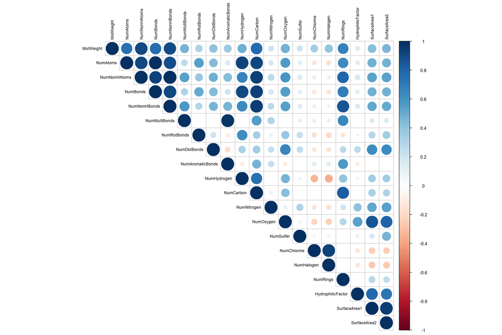

```r
##################################
# Loading dataset
##################################
DPA <- Solubility_Train

##################################
# Listing all predictors
##################################
DPA.Predictors <- DPA[,!names(DPA) %in% c("solTrainY")]

##################################
# Listing all numeric predictors
##################################
DPA.Predictors.Numeric <- DPA.Predictors[,-(grep("FP", names(DPA.Predictors)))]

##################################
# Visualizing pairwise correlation between predictors
##################################
DPA_CorrelationTest <- cor.mtest(DPA.Predictors.Numeric,
                       method = "pearson",
                       conf.level = .95)

corrplot(cor(DPA.Predictors.Numeric,
             method = "pearson",
             use="pairwise.complete.obs"),
         method = "circle",
         type = "upper",
         order = "original",
         tl.col = "black",
         tl.cex = 0.75,
         tl.srt = 90,
         sig.level = 0.05,
         p.mat = DPA_CorrelationTest$p,
         insig = "blank")
```

```r
##################################
# Identifying the highly correlated variables
##################################
DPA_Correlation <-  cor(DPA.Predictors.Numeric,
                        method = "pearson",
                        use="pairwise.complete.obs")
(DPA_HighlyCorrelatedCount <- sum(abs(DPA_Correlation[upper.tri(DPA_Correlation)]) > 0.95))
```

```
## [1] 3
```

```
## [1] "High correlation observed for 3 pairs of numeric variable(s) with Correlation.Coefficient>0.95."
```

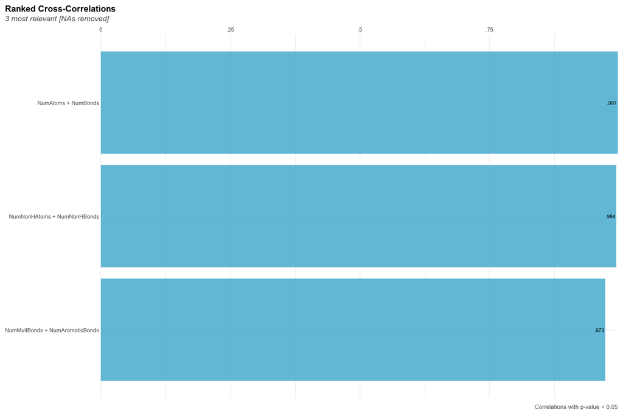

```r
if (DPA_HighlyCorrelatedCount == 0) {
  print("No highly correlated predictors noted.")
} else {
  print(paste0("High correlation observed for ",
               (DPA_HighlyCorrelatedCount),
               " pairs of numeric variable(s) with Correlation.Coefficient>0.95."))

  (DPA_HighlyCorrelatedPairs <- corr_cross(DPA.Predictors.Numeric,
  max_pvalue = 0.05,
  top = DPA_HighlyCorrelatedCount,
  rm.na = TRUE,
  grid = FALSE
))

}
```

```r
if (DPA_HighlyCorrelatedCount > 0) {
  DPA_HighlyCorrelated <- findCorrelation(DPA_Correlation, cutoff = 0.95)

  (DPA_HighlyCorrelatedForRemoval <- length(DPA_HighlyCorrelated))

  print(paste0("High correlation can be resolved by removing ",
               (DPA_HighlyCorrelatedForRemoval),
               " numeric variable(s)."))

  for (j in 1:DPA_HighlyCorrelatedForRemoval) {
  DPA_HighlyCorrelatedRemovedVariable <- colnames(DPA.Predictors.Numeric)[DPA_HighlyCorrelated[j]]
  print(paste0("Variable ",
               j,
               " for removal: ",
               DPA_HighlyCorrelatedRemovedVariable))
  }

  ##################################
  # Filtering out columns with high correlation
  #################################
  DPA_ExcludedHighCorrelation <- DPA[,-DPA_HighlyCorrelated]

  ##################################
  # Gathering descriptive statistics
  ##################################
  (DPA_ExcludedHighCorrelation_Skimmed <- skim(DPA_ExcludedHighCorrelation))

}
```

```
## [1] "High correlation can be resolved by removing 3 numeric variable(s)."
## [1] "Variable 1 for removal: NumNonHAtoms"
## [1] "Variable 2 for removal: NumBonds"
## [1] "Variable 3 for removal: NumAromaticBonds"
```

Data summary

| Name | DPA_ExcludedHighCorrelati… |
| --- | --- |
| Number of rows | 951 |
| Number of columns | 226 |
| _______________________ |  |
| Column type frequency: |  |
| numeric | 226 |
| ________________________ |  |
| Group variables | None |

**Variable type: numeric**

| skim_variable | n_missing | complete_rate | mean | sd | p0 | p25 | p50 | p75 | p100 | hist |
| --- | --- | --- | --- | --- | --- | --- | --- | --- | --- | --- |
| solTrainY | 0 | 1 | -2.72 | 2.05 | -11.62 | -3.96 | -2.51 | -1.36 | 1.58 | ▁▁▃▇▃ |
| FP001 | 0 | 1 | 0.49 | 0.50 | 0.00 | 0.00 | 0.00 | 1.00 | 1.00 | ▇▁▁▁▇ |
| FP004 | 0 | 1 | 0.58 | 0.49 | 0.00 | 0.00 | 1.00 | 1.00 | 1.00 | ▆▁▁▁▇ |
| FP005 | 0 | 1 | 0.58 | 0.49 | 0.00 | 0.00 | 1.00 | 1.00 | 1.00 | ▆▁▁▁▇ |
| FP006 | 0 | 1 | 0.40 | 0.49 | 0.00 | 0.00 | 0.00 | 1.00 | 1.00 | ▇▁▁▁▆ |
| FP007 | 0 | 1 | 0.36 | 0.48 | 0.00 | 0.00 | 0.00 | 1.00 | 1.00 | ▇▁▁▁▅ |
| FP009 | 0 | 1 | 0.28 | 0.45 | 0.00 | 0.00 | 0.00 | 1.00 | 1.00 | ▇▁▁▁▃ |
| FP010 | 0 | 1 | 0.18 | 0.38 | 0.00 | 0.00 | 0.00 | 0.00 | 1.00 | ▇▁▁▁▂ |
| FP011 | 0 | 1 | 0.21 | 0.41 | 0.00 | 0.00 | 0.00 | 0.00 | 1.00 | ▇▁▁▁▂ |
| FP012 | 0 | 1 | 0.18 | 0.38 | 0.00 | 0.00 | 0.00 | 0.00 | 1.00 | ▇▁▁▁▂ |
| FP013 | 0 | 1 | 0.17 | 0.37 | 0.00 | 0.00 | 0.00 | 0.00 | 1.00 | ▇▁▁▁▂ |
| FP014 | 0 | 1 | 0.16 | 0.37 | 0.00 | 0.00 | 0.00 | 0.00 | 1.00 | ▇▁▁▁▂ |
| FP015 | 0 | 1 | 0.86 | 0.35 | 0.00 | 1.00 | 1.00 | 1.00 | 1.00 | ▁▁▁▁▇ |
| FP016 | 0 | 1 | 0.15 | 0.35 | 0.00 | 0.00 | 0.00 | 0.00 | 1.00 | ▇▁▁▁▂ |
| FP017 | 0 | 1 | 0.14 | 0.35 | 0.00 | 0.00 | 0.00 | 0.00 | 1.00 | ▇▁▁▁▂ |
| FP018 | 0 | 1 | 0.13 | 0.34 | 0.00 | 0.00 | 0.00 | 0.00 | 1.00 | ▇▁▁▁▁ |
| FP019 | 0 | 1 | 0.12 | 0.33 | 0.00 | 0.00 | 0.00 | 0.00 | 1.00 | ▇▁▁▁▁ |
| FP020 | 0 | 1 | 0.12 | 0.32 | 0.00 | 0.00 | 0.00 | 0.00 | 1.00 | ▇▁▁▁▁ |
| FP021 | 0 | 1 | 0.12 | 0.33 | 0.00 | 0.00 | 0.00 | 0.00 | 1.00 | ▇▁▁▁▁ |
| FP022 | 0 | 1 | 0.10 | 0.31 | 0.00 | 0.00 | 0.00 | 0.00 | 1.00 | ▇▁▁▁▁ |
| FP023 | 0 | 1 | 0.12 | 0.33 | 0.00 | 0.00 | 0.00 | 0.00 | 1.00 | ▇▁▁▁▁ |
| FP024 | 0 | 1 | 0.11 | 0.32 | 0.00 | 0.00 | 0.00 | 0.00 | 1.00 | ▇▁▁▁▁ |
| FP025 | 0 | 1 | 0.12 | 0.32 | 0.00 | 0.00 | 0.00 | 0.00 | 1.00 | ▇▁▁▁▁ |
| FP026 | 0 | 1 | 0.08 | 0.28 | 0.00 | 0.00 | 0.00 | 0.00 | 1.00 | ▇▁▁▁▁ |
| FP027 | 0 | 1 | 0.10 | 0.30 | 0.00 | 0.00 | 0.00 | 0.00 | 1.00 | ▇▁▁▁▁ |
| FP028 | 0 | 1 | 0.11 | 0.31 | 0.00 | 0.00 | 0.00 | 0.00 | 1.00 | ▇▁▁▁▁ |
| FP029 | 0 | 1 | 0.10 | 0.30 | 0.00 | 0.00 | 0.00 | 0.00 | 1.00 | ▇▁▁▁▁ |
| FP030 | 0 | 1 | 0.09 | 0.29 | 0.00 | 0.00 | 0.00 | 0.00 | 1.00 | ▇▁▁▁▁ |
| FP031 | 0 | 1 | 0.09 | 0.29 | 0.00 | 0.00 | 0.00 | 0.00 | 1.00 | ▇▁▁▁▁ |
| FP032 | 0 | 1 | 0.07 | 0.26 | 0.00 | 0.00 | 0.00 | 0.00 | 1.00 | ▇▁▁▁▁ |

[output cut: 196 more lines]

```r
###################################
# Verifying the data dimensions
###################################
dim(DPA_ExcludedHighCorrelation)
```

```
## [1] 951 226
```

### 1.3.4 Linear Dependencies

**[A]** Linear dependencies noted for 2 subsets of variables using the preprocessing summary from the **caret** package applying the findLinearCombos method which utilizes the QR decomposition of a matrix to enumerate sets of linear combinations (if they exist).  
**[B]** Subset 1  
**[B.1]** NumNonHBonds variable (numeric)  
**[B.2]** NumAtoms variable (numeric)  
**[B.3]** NumNonHAtoms variable (numeric)  
**[B.3]** NumBonds variable (numeric)  
**[C]** Subset 2  
**[C.1]** NumHydrogen variable (numeric)  
**[C.2]** NumAtoms variable (numeric)  
**[C.3]** NumNonHAtoms variable (numeric)

**Code Chunk | Output**

```r
##################################
# Loading dataset
##################################
DPA <- Solubility_Train

##################################
# Listing all predictors
##################################
DPA.Predictors <- DPA[,!names(DPA) %in% c("solTrainY")]

##################################
# Listing all numeric predictors
##################################
DPA.Predictors.Numeric <- DPA.Predictors[,sapply(DPA.Predictors, is.numeric)]

##################################
# Identifying the linearly dependent variables
##################################
DPA_LinearlyDependent <- findLinearCombos(DPA.Predictors.Numeric)

(DPA_LinearlyDependentCount <- length(DPA_LinearlyDependent$linearCombos))
```

```
## [1] 2
```

```r
if (DPA_LinearlyDependentCount == 0) {
  print("No linearly dependent predictors noted.")
} else {
  print(paste0("Linear dependency observed for ",
               (DPA_LinearlyDependentCount),
               " subset(s) of numeric variable(s)."))

  for (i in 1:DPA_LinearlyDependentCount) {
    DPA_LinearlyDependentSubset <- colnames(DPA.Predictors.Numeric)[DPA_LinearlyDependent$linearCombos[[i]]]
    print(paste0("Linear dependent variable(s) for subset ",
                 i,
                 " include: ",
                 DPA_LinearlyDependentSubset))
  }

}
```

```
## [1] "Linear dependency observed for 2 subset(s) of numeric variable(s)."
## [1] "Linear dependent variable(s) for subset 1 include: NumNonHBonds"
## [2] "Linear dependent variable(s) for subset 1 include: NumAtoms"
## [3] "Linear dependent variable(s) for subset 1 include: NumNonHAtoms"
## [4] "Linear dependent variable(s) for subset 1 include: NumBonds"
## [1] "Linear dependent variable(s) for subset 2 include: NumHydrogen"
## [2] "Linear dependent variable(s) for subset 2 include: NumAtoms"
## [3] "Linear dependent variable(s) for subset 2 include: NumNonHAtoms"
```

```r
##################################
# Identifying the linearly dependent variables for removal
##################################

if (DPA_LinearlyDependentCount > 0) {
  DPA_LinearlyDependent <- findLinearCombos(DPA.Predictors.Numeric)

  DPA_LinearlyDependentForRemoval <- length(DPA_LinearlyDependent$remove)

  print(paste0("Linear dependency can be resolved by removing ",
               (DPA_LinearlyDependentForRemoval),
               " numeric variable(s)."))

  for (j in 1:DPA_LinearlyDependentForRemoval) {
  DPA_LinearlyDependentRemovedVariable <- colnames(DPA.Predictors.Numeric)[DPA_LinearlyDependent$remove[j]]
  print(paste0("Variable ",
               j,
               " for removal: ",
               DPA_LinearlyDependentRemovedVariable))
  }

  ##################################
  # Filtering out columns with linear dependency
  #################################
  DPA_ExcludedLinearlyDependent <- DPA[,-DPA_LinearlyDependent$remove]

  ##################################
  # Gathering descriptive statistics
  ##################################
  (DPA_ExcludedLinearlyDependent_Skimmed <- skim(DPA_ExcludedLinearlyDependent))

}
```

```
## [1] "Linear dependency can be resolved by removing 2 numeric variable(s)."
## [1] "Variable 1 for removal: NumNonHBonds"
## [1] "Variable 2 for removal: NumHydrogen"
```

Data summary

| Name | DPA_ExcludedLinearlyDepen… |
| --- | --- |
| Number of rows | 951 |
| Number of columns | 227 |
| _______________________ |  |
| Column type frequency: |  |
| numeric | 227 |
| ________________________ |  |
| Group variables | None |

**Variable type: numeric**

| skim_variable | n_missing | complete_rate | mean | sd | p0 | p25 | p50 | p75 | p100 | hist |
| --- | --- | --- | --- | --- | --- | --- | --- | --- | --- | --- |
| solTrainY | 0 | 1 | -2.72 | 2.05 | -11.62 | -3.96 | -2.51 | -1.36 | 1.58 | ▁▁▃▇▃ |
| FP001 | 0 | 1 | 0.49 | 0.50 | 0.00 | 0.00 | 0.00 | 1.00 | 1.00 | ▇▁▁▁▇ |
| FP002 | 0 | 1 | 0.54 | 0.50 | 0.00 | 0.00 | 1.00 | 1.00 | 1.00 | ▇▁▁▁▇ |
| FP003 | 0 | 1 | 0.44 | 0.50 | 0.00 | 0.00 | 0.00 | 1.00 | 1.00 | ▇▁▁▁▆ |
| FP004 | 0 | 1 | 0.58 | 0.49 | 0.00 | 0.00 | 1.00 | 1.00 | 1.00 | ▆▁▁▁▇ |
| FP005 | 0 | 1 | 0.58 | 0.49 | 0.00 | 0.00 | 1.00 | 1.00 | 1.00 | ▆▁▁▁▇ |
| FP006 | 0 | 1 | 0.40 | 0.49 | 0.00 | 0.00 | 0.00 | 1.00 | 1.00 | ▇▁▁▁▆ |
| FP007 | 0 | 1 | 0.36 | 0.48 | 0.00 | 0.00 | 0.00 | 1.00 | 1.00 | ▇▁▁▁▅ |
| FP008 | 0 | 1 | 0.33 | 0.47 | 0.00 | 0.00 | 0.00 | 1.00 | 1.00 | ▇▁▁▁▃ |
| FP009 | 0 | 1 | 0.28 | 0.45 | 0.00 | 0.00 | 0.00 | 1.00 | 1.00 | ▇▁▁▁▃ |
| FP010 | 0 | 1 | 0.18 | 0.38 | 0.00 | 0.00 | 0.00 | 0.00 | 1.00 | ▇▁▁▁▂ |
| FP011 | 0 | 1 | 0.21 | 0.41 | 0.00 | 0.00 | 0.00 | 0.00 | 1.00 | ▇▁▁▁▂ |
| FP012 | 0 | 1 | 0.18 | 0.38 | 0.00 | 0.00 | 0.00 | 0.00 | 1.00 | ▇▁▁▁▂ |
| FP013 | 0 | 1 | 0.17 | 0.37 | 0.00 | 0.00 | 0.00 | 0.00 | 1.00 | ▇▁▁▁▂ |
| FP014 | 0 | 1 | 0.16 | 0.37 | 0.00 | 0.00 | 0.00 | 0.00 | 1.00 | ▇▁▁▁▂ |
| FP015 | 0 | 1 | 0.86 | 0.35 | 0.00 | 1.00 | 1.00 | 1.00 | 1.00 | ▁▁▁▁▇ |
| FP016 | 0 | 1 | 0.15 | 0.35 | 0.00 | 0.00 | 0.00 | 0.00 | 1.00 | ▇▁▁▁▂ |
| FP017 | 0 | 1 | 0.14 | 0.35 | 0.00 | 0.00 | 0.00 | 0.00 | 1.00 | ▇▁▁▁▂ |
| FP018 | 0 | 1 | 0.13 | 0.34 | 0.00 | 0.00 | 0.00 | 0.00 | 1.00 | ▇▁▁▁▁ |
| FP019 | 0 | 1 | 0.12 | 0.33 | 0.00 | 0.00 | 0.00 | 0.00 | 1.00 | ▇▁▁▁▁ |
| FP020 | 0 | 1 | 0.12 | 0.32 | 0.00 | 0.00 | 0.00 | 0.00 | 1.00 | ▇▁▁▁▁ |
| FP021 | 0 | 1 | 0.12 | 0.33 | 0.00 | 0.00 | 0.00 | 0.00 | 1.00 | ▇▁▁▁▁ |
| FP022 | 0 | 1 | 0.10 | 0.31 | 0.00 | 0.00 | 0.00 | 0.00 | 1.00 | ▇▁▁▁▁ |
| FP023 | 0 | 1 | 0.12 | 0.33 | 0.00 | 0.00 | 0.00 | 0.00 | 1.00 | ▇▁▁▁▁ |
| FP024 | 0 | 1 | 0.11 | 0.32 | 0.00 | 0.00 | 0.00 | 0.00 | 1.00 | ▇▁▁▁▁ |
| FP025 | 0 | 1 | 0.12 | 0.32 | 0.00 | 0.00 | 0.00 | 0.00 | 1.00 | ▇▁▁▁▁ |
| FP026 | 0 | 1 | 0.08 | 0.28 | 0.00 | 0.00 | 0.00 | 0.00 | 1.00 | ▇▁▁▁▁ |
| FP027 | 0 | 1 | 0.10 | 0.30 | 0.00 | 0.00 | 0.00 | 0.00 | 1.00 | ▇▁▁▁▁ |
| FP028 | 0 | 1 | 0.11 | 0.31 | 0.00 | 0.00 | 0.00 | 0.00 | 1.00 | ▇▁▁▁▁ |
| FP029 | 0 | 1 | 0.10 | 0.30 | 0.00 | 0.00 | 0.00 | 0.00 | 1.00 | ▇▁▁▁▁ |

[output cut: 197 more lines]

```r
###################################
# Verifying the data dimensions
###################################
dim(DPA_ExcludedLinearlyDependent)
```

```
## [1] 951 227
```

### 1.3.5 Shape Transformation

**Code Chunk | Output**

```r
##################################
# Loading dataset
##################################
DPA <- Solubility_Train

##################################
# Listing all predictors
##################################
DPA.Predictors <- DPA[,!names(DPA) %in% c("solTrainY")]

##################################
# Listing all numeric predictors
##################################
DPA.Predictors.Numeric <- DPA.Predictors[,-(grep("FP", names(DPA.Predictors)))]

##################################
# Applying a Box-Cox transformation
##################################
DPA_BoxCox <- preProcess(DPA.Predictors.Numeric, method = c("BoxCox"))
DPA_BoxCoxTransformed <- predict(DPA_BoxCox, DPA.Predictors.Numeric)

##################################
# Gathering descriptive statistics
##################################
(DPA_BoxCoxTransformedSkimmed <- skim(DPA_BoxCoxTransformed))
```

Data summary

| Name | DPA_BoxCoxTransformed |
| --- | --- |
| Number of rows | 951 |
| Number of columns | 20 |
| _______________________ |  |
| Column type frequency: |  |
| numeric | 20 |
| ________________________ |  |
| Group variables | None |

**Variable type: numeric**

| skim_variable | n_missing | complete_rate | mean | sd | p0 | p25 | p50 | p75 | p100 | hist |
| --- | --- | --- | --- | --- | --- | --- | --- | --- | --- | --- |
| MolWeight | 0 | 1 | 5.19 | 0.48 | 3.83 | 4.81 | 5.19 | 5.58 | 6.50 | ▁▆▇▆▁ |
| NumAtoms | 0 | 1 | 3.13 | 0.48 | 1.61 | 2.83 | 3.09 | 3.43 | 4.54 | ▁▃▇▃▁ |
| NumNonHAtoms | 0 | 1 | 2.46 | 0.50 | 0.69 | 2.08 | 2.48 | 2.83 | 3.85 | ▁▃▇▇▁ |
| NumBonds | 0 | 1 | 4.39 | 0.96 | 1.60 | 3.81 | 4.36 | 4.97 | 7.48 | ▁▅▇▃▁ |
| NumNonHBonds | 0 | 1 | 3.21 | 0.95 | 0.00 | 2.58 | 3.22 | 3.91 | 5.93 | ▁▃▇▆▁ |
| NumMultBonds | 0 | 1 | 6.15 | 5.17 | 0.00 | 1.00 | 6.00 | 10.00 | 25.00 | ▇▆▃▁▁ |
| NumRotBonds | 0 | 1 | 2.25 | 2.41 | 0.00 | 0.00 | 2.00 | 3.50 | 16.00 | ▇▂▁▁▁ |
| NumDblBonds | 0 | 1 | 1.01 | 1.21 | 0.00 | 0.00 | 1.00 | 2.00 | 7.00 | ▇▂▁▁▁ |
| NumAromaticBonds | 0 | 1 | 5.12 | 5.26 | 0.00 | 0.00 | 6.00 | 6.00 | 25.00 | ▇▆▃▁▁ |
| NumHydrogen | 0 | 1 | 12.35 | 7.32 | 0.00 | 7.00 | 11.00 | 16.00 | 47.00 | ▇▇▂▁▁ |
| NumCarbon | 0 | 1 | 3.54 | 1.34 | 0.00 | 2.62 | 3.52 | 4.25 | 7.62 | ▂▇▇▃▁ |
| NumNitrogen | 0 | 1 | 0.81 | 1.19 | 0.00 | 0.00 | 0.00 | 1.00 | 6.00 | ▇▂▁▁▁ |
| NumOxygen | 0 | 1 | 1.57 | 1.73 | 0.00 | 0.00 | 1.00 | 2.00 | 13.00 | ▇▂▁▁▁ |
| NumSulfer | 0 | 1 | 0.16 | 0.49 | 0.00 | 0.00 | 0.00 | 0.00 | 4.00 | ▇▁▁▁▁ |
| NumChlorine | 0 | 1 | 0.56 | 1.40 | 0.00 | 0.00 | 0.00 | 0.00 | 10.00 | ▇▁▁▁▁ |
| NumHalogen | 0 | 1 | 0.70 | 1.47 | 0.00 | 0.00 | 0.00 | 1.00 | 10.00 | ▇▁▁▁▁ |
| NumRings | 0 | 1 | 1.40 | 1.30 | 0.00 | 0.00 | 1.00 | 2.00 | 7.00 | ▇▃▂▁▁ |
| HydrophilicFactor | 0 | 1 | -0.02 | 1.13 | -0.98 | -0.76 | -0.31 | 0.31 | 13.48 | ▇▁▁▁▁ |
| SurfaceArea1 | 0 | 1 | 36.46 | 35.29 | 0.00 | 9.23 | 29.10 | 53.28 | 331.94 | ▇▂▁▁▁ |
| SurfaceArea2 | 0 | 1 | 40.23 | 38.12 | 0.00 | 10.63 | 33.12 | 60.66 | 331.94 | ▇▂▁▁▁ |

```r
###################################
# Verifying the data dimensions
###################################
dim(DPA_BoxCoxTransformed)
```

```
## [1] 951  20
```

### 1.3.6 Centering and Scaling

**[A]** To maintain numerical stability during modelling, centering and scaling transformations were applied on the transformed numeric variables. The center method from the **caret** package was implemented which subtracts the average value of a numeric variable to all the values. As a result of centering, the variables had zero mean values. In addition, the scale method, also from the **caret** package, was applied which performs a center transformation with each value of the variable divided by its standard deviation. Scaling the data coerced the values to have a common standard deviation of one.

**Code Chunk | Output**

```r
##################################
# Loading dataset
##################################
DPA <- Solubility_Train

##################################
# Listing all predictors
##################################
DPA.Predictors <- DPA[,!names(DPA) %in% c("solTrainY")]

##################################
# Listing all numeric predictors
##################################
DPA.Predictors.Numeric <- DPA.Predictors[,-(grep("FP", names(DPA.Predictors)))]

##################################
# Applying a Box-Cox transformation
##################################
DPA_BoxCox <- preProcess(DPA.Predictors.Numeric, method = c("BoxCox"))
DPA_BoxCoxTransformed <- predict(DPA_BoxCox, DPA.Predictors.Numeric)

##################################
# Applying a center and scale data transformation
##################################
DPA.Predictors.Numeric_BoxCoxTransformed_CenteredScaled <- preProcess(DPA_BoxCoxTransformed, method = c("center","scale"))
DPA.Predictors.Numeric_BoxCoxTransformed_CenteredScaledTransformed <- predict(DPA.Predictors.Numeric_BoxCoxTransformed_CenteredScaled, DPA_BoxCoxTransformed)

##################################
# Gathering descriptive statistics
##################################
(DPA.Predictors.Numeric_BoxCoxTransformed_CenteredScaledTransformedSkimmed <- skim(DPA.Predictors.Numeric_BoxCoxTransformed_CenteredScaledTransformed))
```

Data summary

| Name | DPA.Predictors.Numeric_Bo… |
| --- | --- |
| Number of rows | 951 |
| Number of columns | 20 |
| _______________________ |  |
| Column type frequency: |  |
| numeric | 20 |
| ________________________ |  |
| Group variables | None |

**Variable type: numeric**

| skim_variable | n_missing | complete_rate | mean | sd | p0 | p25 | p50 | p75 | p100 | hist |
| --- | --- | --- | --- | --- | --- | --- | --- | --- | --- | --- |
| MolWeight | 0 | 1 | 0 | 1 | -2.84 | -0.80 | -0.01 | 0.80 | 2.72 | ▁▆▇▆▁ |
| NumAtoms | 0 | 1 | 0 | 1 | -3.16 | -0.61 | -0.07 | 0.64 | 2.95 | ▁▃▇▃▁ |
| NumNonHAtoms | 0 | 1 | 0 | 1 | -3.53 | -0.76 | 0.06 | 0.75 | 2.79 | ▁▃▇▇▁ |
| NumBonds | 0 | 1 | 0 | 1 | -2.92 | -0.61 | -0.04 | 0.60 | 3.23 | ▁▅▇▃▁ |
| NumNonHBonds | 0 | 1 | 0 | 1 | -3.38 | -0.67 | 0.01 | 0.74 | 2.86 | ▁▃▇▆▁ |
| NumMultBonds | 0 | 1 | 0 | 1 | -1.19 | -1.00 | -0.03 | 0.74 | 3.65 | ▇▇▃▁▁ |
| NumRotBonds | 0 | 1 | 0 | 1 | -0.93 | -0.93 | -0.10 | 0.52 | 5.71 | ▇▂▁▁▁ |
| NumDblBonds | 0 | 1 | 0 | 1 | -0.83 | -0.83 | -0.01 | 0.82 | 4.95 | ▇▂▁▁▁ |
| NumAromaticBonds | 0 | 1 | 0 | 1 | -0.97 | -0.97 | 0.17 | 0.17 | 3.78 | ▇▆▃▁▁ |
| NumHydrogen | 0 | 1 | 0 | 1 | -1.69 | -0.73 | -0.18 | 0.50 | 4.74 | ▇▇▂▁▁ |
| NumCarbon | 0 | 1 | 0 | 1 | -2.64 | -0.69 | -0.01 | 0.54 | 3.06 | ▂▇▇▃▁ |
| NumNitrogen | 0 | 1 | 0 | 1 | -0.69 | -0.69 | -0.69 | 0.16 | 4.37 | ▇▂▁▁▁ |
| NumOxygen | 0 | 1 | 0 | 1 | -0.91 | -0.91 | -0.33 | 0.25 | 6.61 | ▇▂▁▁▁ |
| NumSulfer | 0 | 1 | 0 | 1 | -0.34 | -0.34 | -0.34 | -0.34 | 7.86 | ▇▁▁▁▁ |
| NumChlorine | 0 | 1 | 0 | 1 | -0.40 | -0.40 | -0.40 | -0.40 | 6.74 | ▇▁▁▁▁ |
| NumHalogen | 0 | 1 | 0 | 1 | -0.47 | -0.47 | -0.47 | 0.20 | 6.32 | ▇▁▁▁▁ |
| NumRings | 0 | 1 | 0 | 1 | -1.08 | -1.08 | -0.31 | 0.46 | 4.31 | ▇▃▂▁▁ |
| HydrophilicFactor | 0 | 1 | 0 | 1 | -0.86 | -0.66 | -0.26 | 0.30 | 11.99 | ▇▁▁▁▁ |
| SurfaceArea1 | 0 | 1 | 0 | 1 | -1.03 | -0.77 | -0.21 | 0.48 | 8.37 | ▇▂▁▁▁ |
| SurfaceArea2 | 0 | 1 | 0 | 1 | -1.06 | -0.78 | -0.19 | 0.54 | 7.65 | ▇▂▁▁▁ |

```r
###################################
# Verifying the data dimensions
###################################
dim(DPA.Predictors.Numeric_BoxCoxTransformed_CenteredScaledTransformed)
```

```
## [1] 951  20
```

### 1.3.7 Pre-Processed Dataset

**[A]** 1267 rows (observations)  
**[A.1]** Train Set = 951 observations  
**[A.2]** Test Set = 316 observations  
**[B]** 221 columns (variables)  
**[B.1]** 1/221 response = Class variable (numeric)  
**[B.2]** 220/221 predictors = All remaining variables (205/220 factor + 15/220 numeric)  
**[C]** Pre-processing actions applied:  
**[C.1]** Centering, scaling and shape transformation applied to improve data quality  
**[C.2]** No outlier treatment applied since the high values noted were contextually valid and sensible  
**[C.3]** 3 predictors removed due to zero or near-zero variance  
**[C.4]** 3 predictors removed due to high correlation  
**[C.5]** 2 predictors removed due to linear dependencies

**Code Chunk | Output**

```r
##################################
# Creating the pre-modelling
# train set
##################################
Log_Solubility <- DPA$solTrainY
PMA.Predictors.Factor   <- DPA.Predictors[,(grep("FP", names(DPA.Predictors)))]
PMA.Predictors.Factor   <- as.data.frame(lapply(PMA.Predictors.Factor,factor))
PMA.Predictors.Numeric  <- DPA.Predictors.Numeric_BoxCoxTransformed_CenteredScaledTransformed
PMA_BoxCoxTransformed_CenteredScaledTransformed <- cbind(Log_Solubility,PMA.Predictors.Factor,PMA.Predictors.Numeric)

##################################
# Filtering out columns noted with data quality issues including
# zero and near-zero variance,
# high correlation and linear dependencies
# to create the pre-modelling dataset
##################################
PMA_BoxCoxTransformed_CenteredScaledTransformed_ExcludedLowVariance_ExcludedLinearlyDependent_ExcludedHighCorrelation <- PMA_BoxCoxTransformed_CenteredScaledTransformed[,!names(PMA_BoxCoxTransformed_CenteredScaledTransformed) %in% c("FP154","FP199","FP200","NumNonHBonds","NumHydrogen","NumNonHAtoms","NumAromaticBonds","NumAtoms")]

PMA_PreModelling_Train <- PMA_BoxCoxTransformed_CenteredScaledTransformed_ExcludedLowVariance_ExcludedLinearlyDependent_ExcludedHighCorrelation

##################################
# Gathering descriptive statistics
##################################
(PMA_PreModelling_Train_Skimmed <- skim(PMA_PreModelling_Train))
```

Data summary

| Name | PMA_PreModelling_Train |
| --- | --- |
| Number of rows | 951 |
| Number of columns | 221 |
| _______________________ |  |
| Column type frequency: |  |
| factor | 205 |
| numeric | 16 |
| ________________________ |  |
| Group variables | None |

**Variable type: factor**

| skim_variable | n_missing | complete_rate | ordered | n_unique | top_counts |
| --- | --- | --- | --- | --- | --- |
| FP001 | 0 | 1 | FALSE | 2 | 0: 482, 1: 469 |
| FP002 | 0 | 1 | FALSE | 2 | 1: 513, 0: 438 |
| FP003 | 0 | 1 | FALSE | 2 | 0: 536, 1: 415 |
| FP004 | 0 | 1 | FALSE | 2 | 1: 556, 0: 395 |
| FP005 | 0 | 1 | FALSE | 2 | 1: 551, 0: 400 |
| FP006 | 0 | 1 | FALSE | 2 | 0: 570, 1: 381 |
| FP007 | 0 | 1 | FALSE | 2 | 0: 605, 1: 346 |
| FP008 | 0 | 1 | FALSE | 2 | 0: 641, 1: 310 |
| FP009 | 0 | 1 | FALSE | 2 | 0: 685, 1: 266 |
| FP010 | 0 | 1 | FALSE | 2 | 0: 781, 1: 170 |
| FP011 | 0 | 1 | FALSE | 2 | 0: 747, 1: 204 |
| FP012 | 0 | 1 | FALSE | 2 | 0: 783, 1: 168 |
| FP013 | 0 | 1 | FALSE | 2 | 0: 793, 1: 158 |
| FP014 | 0 | 1 | FALSE | 2 | 0: 798, 1: 153 |
| FP015 | 0 | 1 | FALSE | 2 | 1: 818, 0: 133 |
| FP016 | 0 | 1 | FALSE | 2 | 0: 812, 1: 139 |
| FP017 | 0 | 1 | FALSE | 2 | 0: 814, 1: 137 |
| FP018 | 0 | 1 | FALSE | 2 | 0: 826, 1: 125 |
| FP019 | 0 | 1 | FALSE | 2 | 0: 835, 1: 116 |
| FP020 | 0 | 1 | FALSE | 2 | 0: 837, 1: 114 |
| FP021 | 0 | 1 | FALSE | 2 | 0: 836, 1: 115 |
| FP022 | 0 | 1 | FALSE | 2 | 0: 852, 1: 99 |
| FP023 | 0 | 1 | FALSE | 2 | 0: 834, 1: 117 |
| FP024 | 0 | 1 | FALSE | 2 | 0: 844, 1: 107 |
| FP025 | 0 | 1 | FALSE | 2 | 0: 841, 1: 110 |
| FP026 | 0 | 1 | FALSE | 2 | 0: 871, 1: 80 |
| FP027 | 0 | 1 | FALSE | 2 | 0: 858, 1: 93 |
| FP028 | 0 | 1 | FALSE | 2 | 0: 850, 1: 101 |
| FP029 | 0 | 1 | FALSE | 2 | 0: 854, 1: 97 |
| FP030 | 0 | 1 | FALSE | 2 | 0: 862, 1: 89 |

[output cut: 175 more lines]

**Variable type: numeric**

| skim_variable | n_missing | complete_rate | mean | sd | p0 | p25 | p50 | p75 | p100 | hist |
| --- | --- | --- | --- | --- | --- | --- | --- | --- | --- | --- |
| Log_Solubility | 0 | 1 | -2.72 | 2.05 | -11.62 | -3.96 | -2.51 | -1.36 | 1.58 | ▁▁▃▇▃ |
| MolWeight | 0 | 1 | 0.00 | 1.00 | -2.84 | -0.80 | -0.01 | 0.80 | 2.72 | ▁▆▇▆▁ |
| NumBonds | 0 | 1 | 0.00 | 1.00 | -2.92 | -0.61 | -0.04 | 0.60 | 3.23 | ▁▅▇▃▁ |
| NumMultBonds | 0 | 1 | 0.00 | 1.00 | -1.19 | -1.00 | -0.03 | 0.74 | 3.65 | ▇▇▃▁▁ |
| NumRotBonds | 0 | 1 | 0.00 | 1.00 | -0.93 | -0.93 | -0.10 | 0.52 | 5.71 | ▇▂▁▁▁ |
| NumDblBonds | 0 | 1 | 0.00 | 1.00 | -0.83 | -0.83 | -0.01 | 0.82 | 4.95 | ▇▂▁▁▁ |
| NumCarbon | 0 | 1 | 0.00 | 1.00 | -2.64 | -0.69 | -0.01 | 0.54 | 3.06 | ▂▇▇▃▁ |
| NumNitrogen | 0 | 1 | 0.00 | 1.00 | -0.69 | -0.69 | -0.69 | 0.16 | 4.37 | ▇▂▁▁▁ |
| NumOxygen | 0 | 1 | 0.00 | 1.00 | -0.91 | -0.91 | -0.33 | 0.25 | 6.61 | ▇▂▁▁▁ |
| NumSulfer | 0 | 1 | 0.00 | 1.00 | -0.34 | -0.34 | -0.34 | -0.34 | 7.86 | ▇▁▁▁▁ |
| NumChlorine | 0 | 1 | 0.00 | 1.00 | -0.40 | -0.40 | -0.40 | -0.40 | 6.74 | ▇▁▁▁▁ |
| NumHalogen | 0 | 1 | 0.00 | 1.00 | -0.47 | -0.47 | -0.47 | 0.20 | 6.32 | ▇▁▁▁▁ |
| NumRings | 0 | 1 | 0.00 | 1.00 | -1.08 | -1.08 | -0.31 | 0.46 | 4.31 | ▇▃▂▁▁ |
| HydrophilicFactor | 0 | 1 | 0.00 | 1.00 | -0.86 | -0.66 | -0.26 | 0.30 | 11.99 | ▇▁▁▁▁ |
| SurfaceArea1 | 0 | 1 | 0.00 | 1.00 | -1.03 | -0.77 | -0.21 | 0.48 | 8.37 | ▇▂▁▁▁ |
| SurfaceArea2 | 0 | 1 | 0.00 | 1.00 | -1.06 | -0.78 | -0.19 | 0.54 | 7.65 | ▇▂▁▁▁ |

```r
###################################
# Verifying the data dimensions
# for the train set
###################################
dim(PMA_PreModelling_Train)
```

```
## [1] 951 221
```

```r
##################################
# Formulating the test set
##################################
DPA_Test <- Solubility_Test
DPA_Test.Predictors <- DPA_Test[,!names(DPA_Test) %in% c("solTestY")]
DPA_Test.Predictors.Numeric <- DPA_Test.Predictors[,-(grep("FP", names(DPA_Test.Predictors)))]
DPA_Test_BoxCox <- preProcess(DPA_Test.Predictors.Numeric, method = c("BoxCox"))
DPA_Test_BoxCoxTransformed <- predict(DPA_Test_BoxCox, DPA_Test.Predictors.Numeric)
DPA_Test.Predictors.Numeric_BoxCoxTransformed_CenteredScaled <- preProcess(DPA_Test_BoxCoxTransformed, method = c("center","scale"))
DPA_Test.Predictors.Numeric_BoxCoxTransformed_CenteredScaledTransformed <- predict(DPA_Test.Predictors.Numeric_BoxCoxTransformed_CenteredScaled, DPA_Test_BoxCoxTransformed)

##################################
# Creating the pre-modelling
# train set
##################################
Log_Solubility <- DPA_Test$solTestY
PMA_Test.Predictors.Factor   <- DPA_Test.Predictors[,(grep("FP", names(DPA_Test.Predictors)))]
PMA_Test.Predictors.Factor   <- as.data.frame(lapply(PMA_Test.Predictors.Factor,factor))
PMA_Test.Predictors.Numeric  <- DPA_Test.Predictors.Numeric_BoxCoxTransformed_CenteredScaledTransformed
PMA_Test_BoxCoxTransformed_CenteredScaledTransformed <- cbind(Log_Solubility,PMA_Test.Predictors.Factor,PMA_Test.Predictors.Numeric)
PMA_Test_BoxCoxTransformed_CenteredScaledTransformed_ExcludedLowVariance_ExcludedLinearlyDependent_ExcludedHighCorrelation <- PMA_Test_BoxCoxTransformed_CenteredScaledTransformed[,!names(PMA_Test_BoxCoxTransformed_CenteredScaledTransformed) %in% c("FP154","FP199","FP200","NumNonHBonds","NumHydrogen","NumNonHAtoms","NumAromaticBonds","NumAtoms")]

PMA_PreModelling_Test <- PMA_Test_BoxCoxTransformed_CenteredScaledTransformed_ExcludedLowVariance_ExcludedLinearlyDependent_ExcludedHighCorrelation

##################################
# Gathering descriptive statistics
##################################
(PMA_PreModelling_Test_Skimmed <- skim(PMA_PreModelling_Test))
```

Data summary

| Name | PMA_PreModelling_Test |
| --- | --- |
| Number of rows | 316 |
| Number of columns | 221 |
| _______________________ |  |
| Column type frequency: |  |
| factor | 205 |
| numeric | 16 |
| ________________________ |  |
| Group variables | None |

**Variable type: factor**

| skim_variable | n_missing | complete_rate | ordered | n_unique | top_counts |
| --- | --- | --- | --- | --- | --- |
| FP001 | 0 | 1 | FALSE | 2 | 0: 168, 1: 148 |
| FP002 | 0 | 1 | FALSE | 2 | 1: 185, 0: 131 |
| FP003 | 0 | 1 | FALSE | 2 | 0: 176, 1: 140 |
| FP004 | 0 | 1 | FALSE | 2 | 1: 168, 0: 148 |
| FP005 | 0 | 1 | FALSE | 2 | 1: 195, 0: 121 |
| FP006 | 0 | 1 | FALSE | 2 | 0: 205, 1: 111 |
| FP007 | 0 | 1 | FALSE | 2 | 0: 204, 1: 112 |
| FP008 | 0 | 1 | FALSE | 2 | 0: 202, 1: 114 |
| FP009 | 0 | 1 | FALSE | 2 | 0: 233, 1: 83 |
| FP010 | 0 | 1 | FALSE | 2 | 0: 255, 1: 61 |
| FP011 | 0 | 1 | FALSE | 2 | 0: 261, 1: 55 |
| FP012 | 0 | 1 | FALSE | 2 | 0: 263, 1: 53 |
| FP013 | 0 | 1 | FALSE | 2 | 0: 264, 1: 52 |
| FP014 | 0 | 1 | FALSE | 2 | 0: 266, 1: 50 |
| FP015 | 0 | 1 | FALSE | 2 | 1: 262, 0: 54 |
| FP016 | 0 | 1 | FALSE | 2 | 0: 271, 1: 45 |
| FP017 | 0 | 1 | FALSE | 2 | 0: 269, 1: 47 |
| FP018 | 0 | 1 | FALSE | 2 | 0: 289, 1: 27 |
| FP019 | 0 | 1 | FALSE | 2 | 0: 280, 1: 36 |
| FP020 | 0 | 1 | FALSE | 2 | 0: 282, 1: 34 |
| FP021 | 0 | 1 | FALSE | 2 | 0: 282, 1: 34 |
| FP022 | 0 | 1 | FALSE | 2 | 0: 279, 1: 37 |
| FP023 | 0 | 1 | FALSE | 2 | 0: 289, 1: 27 |
| FP024 | 0 | 1 | FALSE | 2 | 0: 285, 1: 31 |
| FP025 | 0 | 1 | FALSE | 2 | 0: 291, 1: 25 |
| FP026 | 0 | 1 | FALSE | 2 | 0: 279, 1: 37 |
| FP027 | 0 | 1 | FALSE | 2 | 0: 291, 1: 25 |
| FP028 | 0 | 1 | FALSE | 2 | 0: 298, 1: 18 |
| FP029 | 0 | 1 | FALSE | 2 | 0: 300, 1: 16 |
| FP030 | 0 | 1 | FALSE | 2 | 0: 290, 1: 26 |

[output cut: 175 more lines]

**Variable type: numeric**

| skim_variable | n_missing | complete_rate | mean | sd | p0 | p25 | p50 | p75 | p100 | hist |
| --- | --- | --- | --- | --- | --- | --- | --- | --- | --- | --- |
| Log_Solubility | 0 | 1 | -2.8 | 2.08 | -10.41 | -3.95 | -2.48 | -1.37 | 1.07 | ▁▁▅▇▅ |
| MolWeight | 0 | 1 | 0.0 | 1.00 | -2.46 | -0.78 | -0.06 | 0.81 | 2.18 | ▁▇▇▇▃ |
| NumBonds | 0 | 1 | 0.0 | 1.00 | -2.92 | -0.67 | 0.03 | 0.57 | 2.55 | ▁▂▇▃▂ |
| NumMultBonds | 0 | 1 | 0.0 | 1.00 | -1.24 | -1.04 | -0.06 | 0.72 | 4.06 | ▇▇▅▁▁ |
| NumRotBonds | 0 | 1 | 0.0 | 1.00 | -0.82 | -0.82 | -0.40 | 0.44 | 5.94 | ▇▁▁▁▁ |
| NumDblBonds | 0 | 1 | 0.0 | 1.00 | -0.76 | -0.76 | 0.09 | 0.09 | 4.35 | ▇▁▁▁▁ |
| NumCarbon | 0 | 1 | 0.0 | 1.00 | -2.71 | -0.70 | -0.21 | 0.56 | 2.23 | ▁▂▇▅▂ |
| NumNitrogen | 0 | 1 | 0.0 | 1.00 | -0.63 | -0.63 | -0.63 | 0.26 | 4.71 | ▇▂▁▁▁ |
| NumOxygen | 0 | 1 | 0.0 | 1.00 | -0.92 | -0.92 | -0.26 | 0.40 | 5.02 | ▇▃▁▁▁ |
| NumSulfer | 0 | 1 | 0.0 | 1.00 | -0.28 | -0.28 | -0.28 | -0.28 | 8.06 | ▇▁▁▁▁ |
| NumChlorine | 0 | 1 | 0.0 | 1.00 | -0.40 | -0.40 | -0.40 | -0.40 | 6.02 | ▇▁▁▁▁ |
| NumHalogen | 0 | 1 | 0.0 | 1.00 | -0.48 | -0.48 | -0.48 | 0.20 | 5.57 | ▇▁▁▁▁ |
| NumRings | 0 | 1 | 0.0 | 1.00 | -1.14 | -0.32 | -0.32 | 0.49 | 3.74 | ▇▃▁▁▁ |
| HydrophilicFactor | 0 | 1 | 0.0 | 1.00 | -0.90 | -0.68 | -0.30 | 0.32 | 5.19 | ▇▂▁▁▁ |
| SurfaceArea1 | 0 | 1 | 0.0 | 1.00 | -1.04 | -0.75 | -0.21 | 0.53 | 5.37 | ▇▃▁▁▁ |
| SurfaceArea2 | 0 | 1 | 0.0 | 1.00 | -1.05 | -0.77 | -0.26 | 0.52 | 5.00 | ▇▃▁▁▁ |

```r
###################################
# Verifying the data dimensions
# for the test set
###################################
dim(PMA_PreModelling_Test)
```

```
## [1] 316 221
```

## 1.4 Data Exploration

**[A]** Numeric variables which demonstrated linear or non-linear relationships with the Log_Solubility response variable include:  
**[A.1]** MolWeight variable (numeric)  
**[A.2]** NumCarbon variable (numeric)  
**[A.3]** NumChlorine variable (numeric)  
**[A.4]** NumHalogen variable (numeric)  
**[A.5]** NumMultBonds variable (numeric)  
**[B]** Factor variables which demonstrated relatively better differentiation of the Log_Solubility response variable between its 1 and 0 structure levels include:  
**[B.1]** FP207 variable (factor)  
**[B.2]** FP190 variable (factor)  
**[B.3]** FP197 variable (factor)  
**[B.4]** FP196 variable (factor)  
**[B.5]** FP193 variable (factor)  
**[B.6]** FP184 variable (factor)  
**[B.7]** FP172 variable (factor)  
**[B.8]** FP149 variable (factor)  
**[B.9]** FP112 variable (factor)  
**[B.10]** FP107 variable (factor)  
**[B.11]** FP089 variable (factor)  
**[B.12]** FP076 variable (factor)  
**[B.13]** FP059 variable (factor)  
**[B.14]** FP049 variable (factor)  
**[B.15]** FP044 variable (factor)  
**[B.16]** FP014 variable (factor)  
**[B.17]** FP013 variable (factor)

**Code Chunk | Output**

```r
##################################
# Loading dataset
##################################
EDA <- PMA_PreModelling_Train

##################################
# Listing all predictors
##################################
EDA.Predictors <- EDA[,!names(EDA) %in% c("Log_Solubility")]

##################################
# Listing all numeric predictors
##################################
EDA.Predictors.Numeric <- EDA.Predictors[,sapply(EDA.Predictors, is.numeric)]
ncol(EDA.Predictors.Numeric)
```

```
## [1] 15
```

```r
names(EDA.Predictors.Numeric)
```

```
##  [1] "MolWeight"         "NumBonds"          "NumMultBonds"
##  [4] "NumRotBonds"       "NumDblBonds"       "NumCarbon"
##  [7] "NumNitrogen"       "NumOxygen"         "NumSulfer"
## [10] "NumChlorine"       "NumHalogen"        "NumRings"
## [13] "HydrophilicFactor" "SurfaceArea1"      "SurfaceArea2"
```

```r
##################################
# Listing all factor predictors
##################################
EDA.Predictors.Factor <- EDA.Predictors[,sapply(EDA.Predictors, is.factor)]
ncol(EDA.Predictors.Factor)
```

```
## [1] 205
```

```r
names(EDA.Predictors.Factor)
```

```
##   [1] "FP001" "FP002" "FP003" "FP004" "FP005" "FP006" "FP007" "FP008" "FP009"
##  [10] "FP010" "FP011" "FP012" "FP013" "FP014" "FP015" "FP016" "FP017" "FP018"
##  [19] "FP019" "FP020" "FP021" "FP022" "FP023" "FP024" "FP025" "FP026" "FP027"
##  [28] "FP028" "FP029" "FP030" "FP031" "FP032" "FP033" "FP034" "FP035" "FP036"
##  [37] "FP037" "FP038" "FP039" "FP040" "FP041" "FP042" "FP043" "FP044" "FP045"
##  [46] "FP046" "FP047" "FP048" "FP049" "FP050" "FP051" "FP052" "FP053" "FP054"
##  [55] "FP055" "FP056" "FP057" "FP058" "FP059" "FP060" "FP061" "FP062" "FP063"
##  [64] "FP064" "FP065" "FP066" "FP067" "FP068" "FP069" "FP070" "FP071" "FP072"
##  [73] "FP073" "FP074" "FP075" "FP076" "FP077" "FP078" "FP079" "FP080" "FP081"
##  [82] "FP082" "FP083" "FP084" "FP085" "FP086" "FP087" "FP088" "FP089" "FP090"
##  [91] "FP091" "FP092" "FP093" "FP094" "FP095" "FP096" "FP097" "FP098" "FP099"
## [100] "FP100" "FP101" "FP102" "FP103" "FP104" "FP105" "FP106" "FP107" "FP108"
## [109] "FP109" "FP110" "FP111" "FP112" "FP113" "FP114" "FP115" "FP116" "FP117"
## [118] "FP118" "FP119" "FP120" "FP121" "FP122" "FP123" "FP124" "FP125" "FP126"
## [127] "FP127" "FP128" "FP129" "FP130" "FP131" "FP132" "FP133" "FP134" "FP135"
## [136] "FP136" "FP137" "FP138" "FP139" "FP140" "FP141" "FP142" "FP143" "FP144"
## [145] "FP145" "FP146" "FP147" "FP148" "FP149" "FP150" "FP151" "FP152" "FP153"
## [154] "FP155" "FP156" "FP157" "FP158" "FP159" "FP160" "FP161" "FP162" "FP163"
## [163] "FP164" "FP165" "FP166" "FP167" "FP168" "FP169" "FP170" "FP171" "FP172"
## [172] "FP173" "FP174" "FP175" "FP176" "FP177" "FP178" "FP179" "FP180" "FP181"
## [181] "FP182" "FP183" "FP184" "FP185" "FP186" "FP187" "FP188" "FP189" "FP190"
## [190] "FP191" "FP192" "FP193" "FP194" "FP195" "FP196" "FP197" "FP198" "FP201"
## [199] "FP202" "FP203" "FP204" "FP205" "FP206" "FP207" "FP208"
```

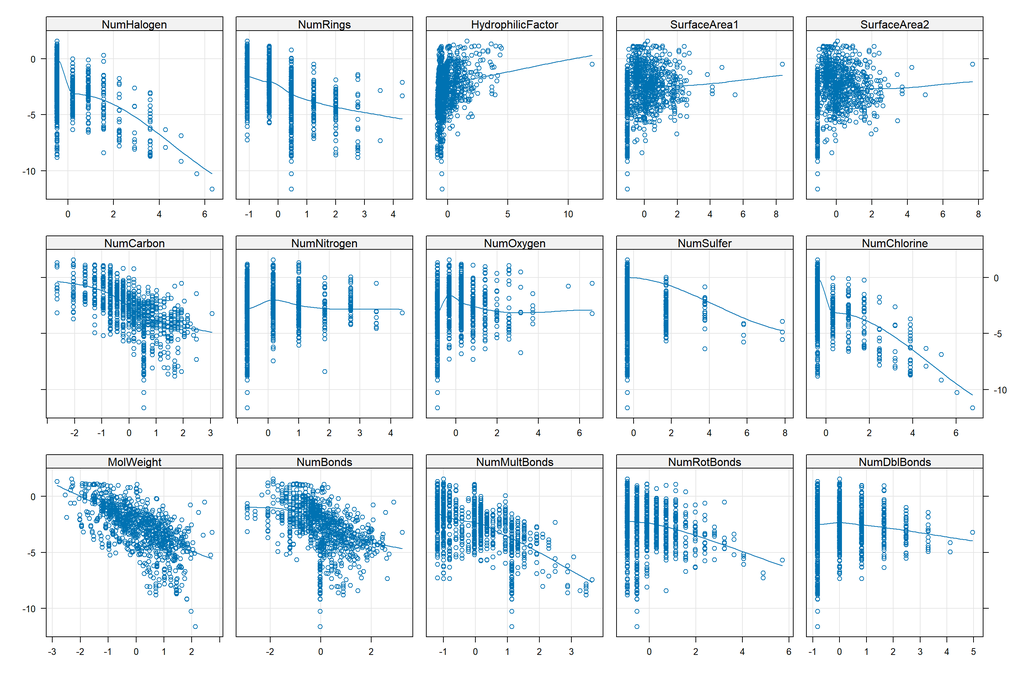

```r
##################################
# Formulating the scatter plots
##################################
featurePlot(x = EDA.Predictors.Numeric,
            y = EDA$Log_Solubility,
            between = list(x = 1, y = 1),
            type = c("g", "p", "smooth"),
            labels = rep("", 2))
```

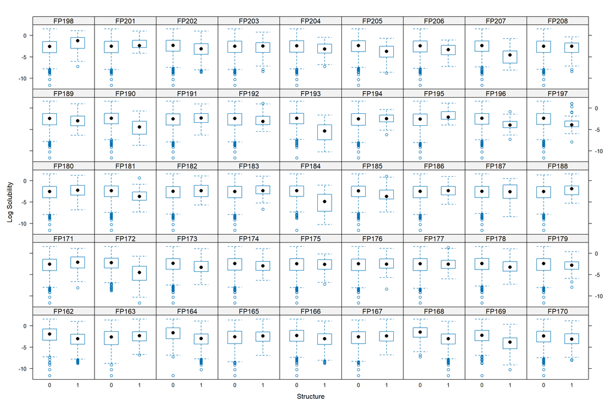

```r
##################################
# Restructuring the dataset for
# for boxplot analysis
##################################
Log_Solubility <- DPA$solTrainY
EDA.Boxplot.Source <- cbind(Log_Solubility,
                     EDA.Predictors.Factor)


EDA.Boxplot.Gathered.Group1 <- gather(EDA.Boxplot.Source,
                                      'FP001','FP002','FP003','FP004','FP005',
                                      'FP006','FP007','FP008','FP009','FP010',
                                      'FP011','FP012','FP013','FP014','FP015',
                                      'FP016','FP017','FP018','FP019','FP020',
                                      'FP021','FP022','FP023','FP024','FP025',
                                      'FP026','FP027','FP028','FP029','FP030',
                                      'FP031','FP032','FP033','FP034','FP035',
                                      'FP036','FP037','FP038','FP039','FP040',
                                      key="Descriptor",
                                      value="Structure")

EDA.Boxplot.Gathered.Group2 <- gather(EDA.Boxplot.Source,
                                      'FP041','FP042','FP043','FP044','FP045',
                                      'FP046','FP047','FP048','FP049','FP050',
                                      'FP051','FP052','FP053','FP054','FP055',
                                      'FP056','FP057','FP058','FP059','FP060',
                                      'FP061','FP062','FP063','FP064','FP065',
                                      'FP066','FP067','FP068','FP069','FP070',
                                      'FP071','FP072','FP073','FP074','FP075',
                                      'FP076','FP077','FP078','FP079','FP080',
                                      key="Descriptor",
                                      value="Structure")

EDA.Boxplot.Gathered.Group3 <- gather(EDA.Boxplot.Source,
                                      'FP081','FP082','FP083','FP084','FP085',
                                      'FP086','FP087','FP088','FP089','FP090',
                                      'FP091','FP092','FP093','FP094','FP095',
                                      'FP096','FP097','FP098','FP099','FP100',
                                      'FP101','FP102','FP103','FP104','FP105',
                                      'FP106','FP107','FP108','FP109','FP110',
                                      'FP111','FP112','FP113','FP114','FP115',
                                      'FP116','FP117','FP118','FP119','FP120',
                                      key="Descriptor",
                                      value="Structure")

EDA.Boxplot.Gathered.Group4 <- gather(EDA.Boxplot.Source,
                                      'FP121','FP122','FP123','FP124','FP125',
                                      'FP126','FP127','FP128','FP129','FP130',
                                      'FP131','FP132','FP133','FP134','FP135',
                                      'FP136','FP137','FP138','FP139','FP140',
                                      'FP141','FP142','FP143','FP144','FP145',
                                      'FP146','FP147','FP148','FP149','FP150',
                                      'FP151','FP152','FP153','FP155','FP156',
                                      'FP157','FP158','FP159','FP160','FP161',
                                      key="Descriptor",
                                      value="Structure")

EDA.Boxplot.Gathered.Group5 <- gather(EDA.Boxplot.Source,
                                      'FP162','FP163','FP164','FP165','FP166',
                                      'FP167','FP168','FP169','FP170','FP171',
                                      'FP172','FP173','FP174','FP175','FP176',
                                      'FP177','FP178','FP179','FP180','FP181',
                                      'FP182','FP183','FP184','FP185','FP186',
                                      'FP187','FP188','FP189','FP190','FP191',
                                      'FP192','FP193','FP194','FP195','FP196',
                                      'FP197','FP198','FP201','FP202','FP203',
                                      'FP204','FP205','FP206','FP207','FP208',
                                      key="Descriptor",
                                      value="Structure")

bwplot(Log_Solubility~Structure|Descriptor,
       data=EDA.Boxplot.Gathered.Group5,
       ylab="Log Solubility",
       xlab="Structure",
       layout=(c(9,5)))
```

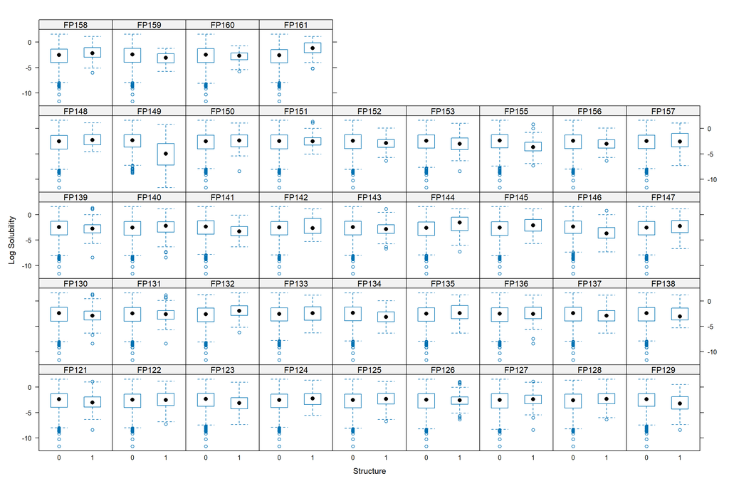

```r
bwplot(Log_Solubility~Structure|Descriptor,
       data=EDA.Boxplot.Gathered.Group4,
       ylab="Log Solubility",
       xlab="Structure",
       layout=(c(9,5)))
```

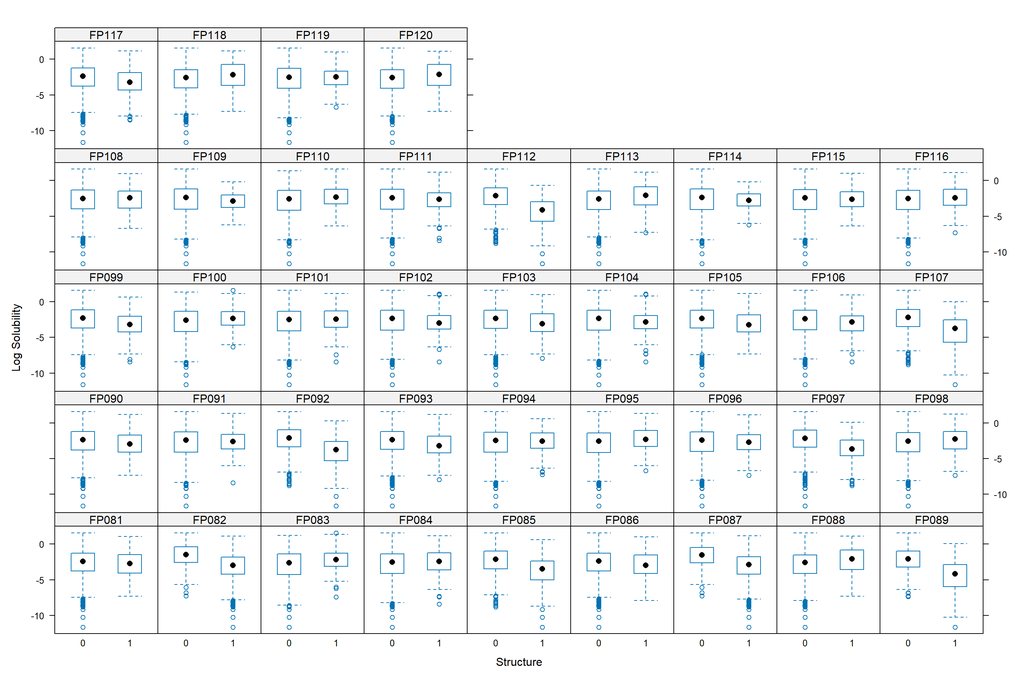

```r
bwplot(Log_Solubility~Structure|Descriptor,
       data=EDA.Boxplot.Gathered.Group3,
       ylab="Log Solubility",
       xlab="Structure",
       layout=(c(9,5)))
```

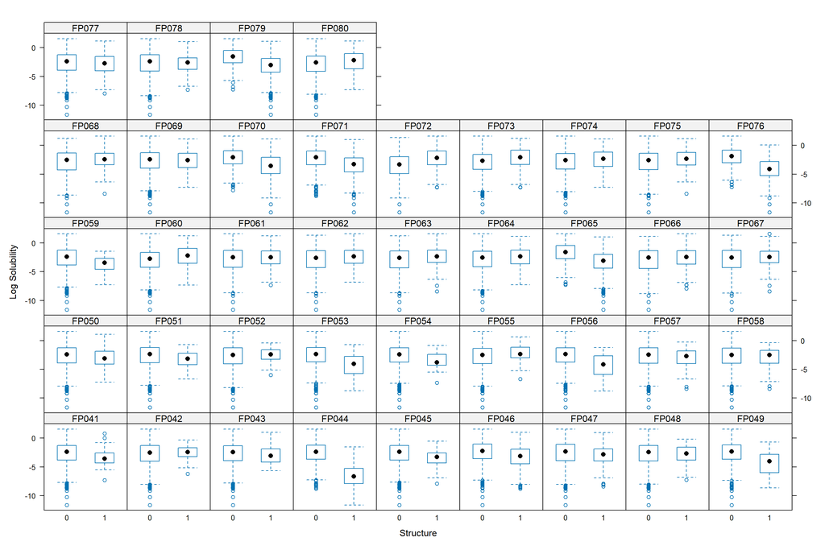

```r
bwplot(Log_Solubility~Structure|Descriptor,
       data=EDA.Boxplot.Gathered.Group2,
       ylab="Log Solubility",
       xlab="Structure",
       layout=(c(9,5)))
```

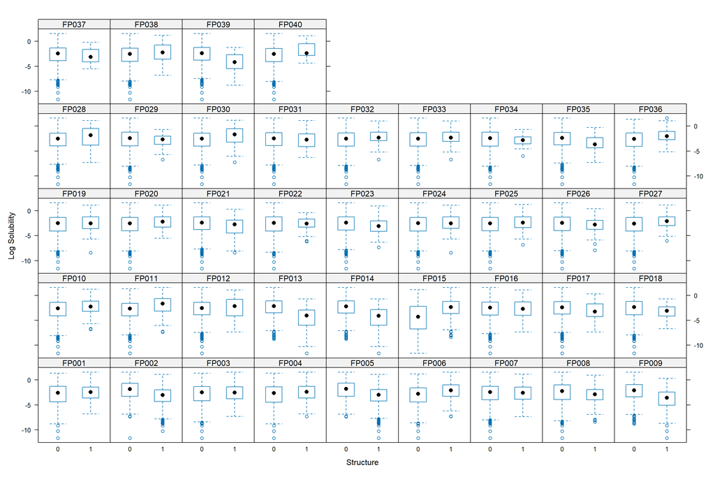

```r
bwplot(Log_Solubility~Structure|Descriptor,
       data=EDA.Boxplot.Gathered.Group1,
       ylab="Log Solubility",
       xlab="Structure",
       layout=(c(9,5)))
```

## 1.5 Model-Independent Feature Importance Metrics

### 1.5.1 Locally Weighted Scatterplot Smoothing Pseudo-R-Squared (LOWESS_PR)

[Locally Weighted Scatterplot Smoothing Pseudo-R-Squared](https://www.tandfonline.com/doi/abs/10.1080/01621459.1979.10481038) computes the R-squared statistic - a goodness-of-fit measure which represents explained variability, improvement from null to fitted model and square of the correlation on predicted values obtained from a locally weighted scatterplot smoothing process. LOWESS consists of computing a series of local linear regressions, with each local regression restricted to a window of x-values. Smoothness is achieved by using overlapping windows and by gradually down-weighting points in each regression according to their distance from the anchor point of the window (tri-cube weighting).  
**[A]** The locally weighted scatterplot smoothing pseudo-r-squared statistic was obtained using the **caret** package. High raw values of the metric indicate that the numeric predictors were associated with the numeric response.  
**[B]** The numeric predictors which demonstrated the best feature importance in terms of this metric are as follows:  
**[B.1]** MolWeight = 0.44437  
**[B.2]** NumCarbon = 0.36580  
**[B.3]** NumMultBonds = 0.27588  
**[B.4]** NumHalogen = 0.25415  
**[B.5]** NumChlorine = 0.25407

**Code Chunk | Output**

```r
##################################
# Filtering in the numeric predictors
# with the numeric response variable
##################################
PMA_PreModelling_Train_Numeric <- PMA_PreModelling_Train[,!grepl("FP", names(PMA_PreModelling_Train))]
dim(PMA_PreModelling_Train_Numeric)
```

```
## [1] 951  16
```

```r
str(PMA_PreModelling_Train_Numeric)
```

```
## 'data.frame':    951 obs. of  16 variables:
##  $ Log_Solubility   : num  -3.97 -3.98 -3.99 -4 -4.06 -4.08 -4.08 -4.1 -4.1 -4.11 ...
##  $ MolWeight        : num  0.304 1.475 0.284 -0.579 0.508 ...
##  $ NumBonds         : num  0.498 1.698 0.697 0.207 0.566 ...
##  $ NumMultBonds     : num  1.9049 1.3248 0.1647 -0.8021 -0.0287 ...
##  $ NumRotBonds      : num  -0.935 0.726 0.726 -0.52 1.141 ...
##  $ NumDblBonds      : num  -0.83134 -0.83134 -0.00521 0.82092 -0.83134 ...
##  $ NumCarbon        : num  0.858 1.804 0.701 0.182 -0.012 ...
##  $ NumNitrogen      : num  1.001 1.844 -0.685 -0.685 3.53 ...
##  $ NumOxygen        : num  -0.91 -0.332 0.246 -0.91 -0.91 ...
##  $ NumSulfer        : num  -0.336 1.712 -0.336 -0.336 -0.336 ...
##  $ NumChlorine      : num  -0.397 -0.397 -0.397 -0.397 0.317 ...
##  $ NumHalogen       : num  -0.474 -0.474 -0.474 -0.474 0.205 ...
##  $ NumRings         : num  1.231 2.001 -0.309 -0.309 -0.309 ...
##  $ HydrophilicFactor: num  -0.742 -0.31 -0.275 -0.834 -0.043 ...
##  $ SurfaceArea1     : num  -0.3026 0.4458 0.0238 -1.0332 0.4954 ...
##  $ SurfaceArea2     : num  -0.379 1.054 -0.077 -1.055 0.36 ...
```

```r
summary(PMA_PreModelling_Train_Numeric)
```

```
##  Log_Solubility      MolWeight            NumBonds        NumMultBonds
##  Min.   :-11.620   Min.   :-2.835229   Min.   :-2.9239   Min.   :-1.18881
##  1st Qu.: -3.955   1st Qu.:-0.798923   1st Qu.:-0.6096   1st Qu.:-0.99545
##  Median : -2.510   Median :-0.008626   Median :-0.0356   Median :-0.02867
##  Mean   : -2.719   Mean   : 0.000000   Mean   : 0.0000   Mean   : 0.00000
##  3rd Qu.: -1.360   3rd Qu.: 0.800109   3rd Qu.: 0.5994   3rd Qu.: 0.74476
##  Max.   :  1.580   Max.   : 2.722778   Max.   : 3.2279   Max.   : 3.64511
##   NumRotBonds       NumDblBonds          NumCarbon         NumNitrogen
##  Min.   :-0.9347   Min.   :-0.831342   Min.   :-2.64433   Min.   :-0.6852
##  1st Qu.:-0.9347   1st Qu.:-0.831342   1st Qu.:-0.68596   1st Qu.:-0.6852
##  Median :-0.1043   Median :-0.005212   Median :-0.01199   Median :-0.6852
##  Mean   : 0.0000   Mean   : 0.000000   Mean   : 0.00000   Mean   : 0.0000
##  3rd Qu.: 0.5184   3rd Qu.: 0.820917   3rd Qu.: 0.53700   3rd Qu.: 0.1578
##  Max.   : 5.7083   Max.   : 4.951564   Max.   : 3.05604   Max.   : 4.3730
##    NumOxygen         NumSulfer       NumChlorine        NumHalogen
##  Min.   :-0.9103   Min.   :-0.336   Min.   :-0.3972   Min.   :-0.4741
##  1st Qu.:-0.9103   1st Qu.:-0.336   1st Qu.:-0.3972   1st Qu.:-0.4741
##  Median :-0.3320   Median :-0.336   Median :-0.3972   Median :-0.4741
##  Mean   : 0.0000   Mean   : 0.000   Mean   : 0.0000   Mean   : 0.0000
##  3rd Qu.: 0.2463   3rd Qu.:-0.336   3rd Qu.:-0.3972   3rd Qu.: 0.2049
##  Max.   : 6.6077   Max.   : 7.858   Max.   : 6.7442   Max.   : 6.3162
##     NumRings       HydrophilicFactor  SurfaceArea1      SurfaceArea2
##  Min.   :-1.0792   Min.   :-0.8565   Min.   :-1.0332   Min.   :-1.0554
##  1st Qu.:-1.0792   1st Qu.:-0.6593   1st Qu.:-0.7716   1st Qu.:-0.7765
##  Median :-0.3093   Median :-0.2606   Median :-0.2085   Median :-0.1866
##  Mean   : 0.0000   Mean   : 0.0000   Mean   : 0.0000   Mean   : 0.0000
##  3rd Qu.: 0.4607   3rd Qu.: 0.2963   3rd Qu.: 0.4767   3rd Qu.: 0.5358
##  Max.   : 4.3103   Max.   :11.9924   Max.   : 8.3733   Max.   : 7.6515
```

```r
##################################
# Obtaining the LOWESS pseudo-R-Squared
##################################
LOWESS_PR <- filterVarImp(x = PMA_PreModelling_Train_Numeric[, 2:ncol(PMA_PreModelling_Train_Numeric)],
                          y = PMA_PreModelling_Train_Numeric$Log_Solubility,
                          nonpara = TRUE)

##################################
# Formulating the summary table
##################################
LOWESS_PR_Summary <- LOWESS_PR

LOWESS_PR_Summary$Predictor <- rownames(LOWESS_PR)
names(LOWESS_PR_Summary)[1] <- "LOWESS_PR"
LOWESS_PR_Summary$Metric <- rep("LOWESS_PR",nrow(LOWESS_PR))

LOWESS_PR_Summary
```

```
##                      LOWESS_PR         Predictor    Metric
## MolWeight         4.443734e-01         MolWeight LOWESS_PR
## NumBonds          2.093744e-01          NumBonds LOWESS_PR
## NumMultBonds      2.758859e-01      NumMultBonds LOWESS_PR
## NumRotBonds       2.230342e-02       NumRotBonds LOWESS_PR
## NumDblBonds       1.530295e-06       NumDblBonds LOWESS_PR
## NumCarbon         3.657997e-01         NumCarbon LOWESS_PR
## NumNitrogen       1.045101e-02       NumNitrogen LOWESS_PR
## NumOxygen         1.710199e-02         NumOxygen LOWESS_PR
## NumSulfer         8.357325e-03         NumSulfer LOWESS_PR
## NumChlorine       2.540713e-01       NumChlorine LOWESS_PR
## NumHalogen        2.541532e-01        NumHalogen LOWESS_PR
## NumRings          2.384330e-01          NumRings LOWESS_PR
## HydrophilicFactor 1.505216e-01 HydrophilicFactor LOWESS_PR
## SurfaceArea1      1.941711e-01      SurfaceArea1 LOWESS_PR
## SurfaceArea2      2.080820e-01      SurfaceArea2 LOWESS_PR
```

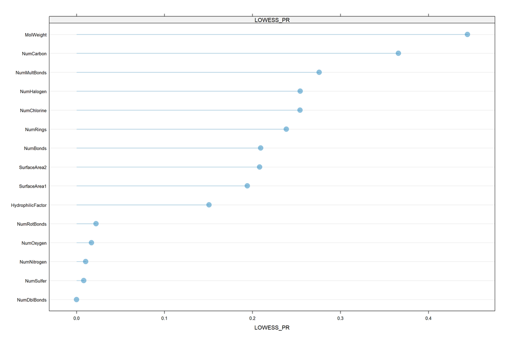

```r
##################################
# Exploring predictor performance
##################################
dotplot(Predictor ~ LOWESS_PR | Metric,
        LOWESS_PR_Summary,
        origin = 0,
        type = c("p", "h"),
        pch = 16,
        cex = 2,
        alpha = 0.45,
        prepanel = function(x, y) {
            list(ylim = levels(reorder(y, x)))
        },
        panel = function(x, y, ...) {
            panel.dotplot(x, reorder(y, x), ...)
        })
```

### 1.5.2 Pearson’s Correlation Coefficient (PCC)

[Pearson’s Correlation Coefficient](https://royalsocietypublishing.org/doi/10.1098/rsta.1896.0007) is a parametric measure of the linear correlation for a pair of features by calculating the ratio between their covariance and the product of their standard deviations. The presence of high absolute correlation values indicate the univariate association between the numeric predictors and the numeric response.  
**[A]** The Pearson’s correlation coefficient was obtained using the **stats** package. High absolute values of the metric indicate that the numeric predictors were associated with the numeric response.  
**[B]** The numeric predictors which demonstrated the best feature importance in terms of this metric are as follows:  
**[B.1]** MolWeight = 0.65849  
**[B.2]** NumCarbon = 0.60481  
**[B.3]** NumMultBonds = 0.52525  
**[B.4]** NumHalogen = 0.50414  
**[B.5]** NumChlorine = 0.50405

**Code Chunk | Output**

```r
##################################
# Obtaining the Pearson correlation coefficient
##################################
PCC <- abs(cor(PMA_PreModelling_Train_Numeric, method="pearson")[-1,1])

##################################
# Formulating the summary table
##################################
PCC_Summary <- data.frame(Predictor = names(PMA_PreModelling_Train_Numeric)[2:ncol(PMA_PreModelling_Train_Numeric)],
                          PCC = PCC,
                          Metric = rep("PCC", length(PCC)))

PCC_Summary
```

```
##                           Predictor         PCC Metric
## MolWeight                 MolWeight 0.658495868    PCC
## NumBonds                   NumBonds 0.457574429    PCC
## NumMultBonds           NumMultBonds 0.525248387    PCC
## NumRotBonds             NumRotBonds 0.149343282    PCC
## NumDblBonds             NumDblBonds 0.001237051    PCC
## NumCarbon                 NumCarbon 0.604813811    PCC
## NumNitrogen             NumNitrogen 0.102230176    PCC
## NumOxygen                 NumOxygen 0.130774566    PCC
## NumSulfer                 NumSulfer 0.091418407    PCC
## NumChlorine             NumChlorine 0.504054819    PCC
## NumHalogen               NumHalogen 0.504136055    PCC
## NumRings                   NumRings 0.488295986    PCC
## HydrophilicFactor HydrophilicFactor 0.309022159    PCC
## SurfaceArea1           SurfaceArea1 0.193769382    PCC
## SurfaceArea2           SurfaceArea2 0.143941883    PCC
```

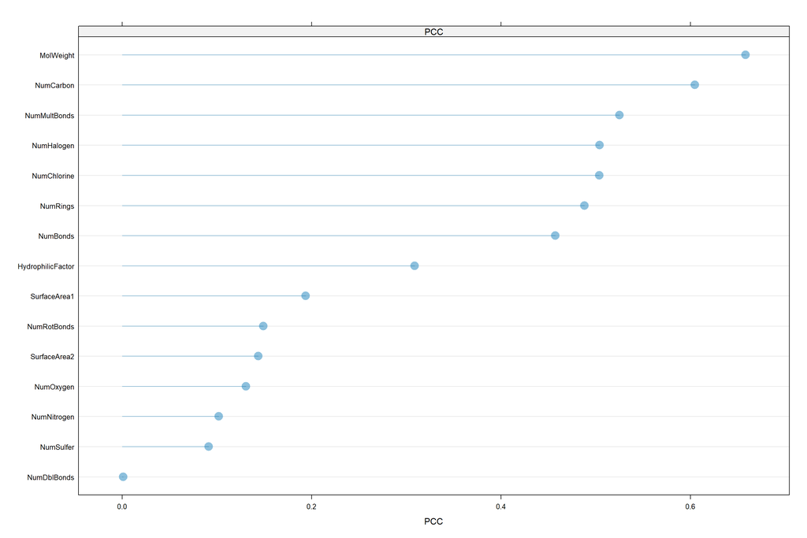

```r
##################################
# Exploring predictor performance
##################################
dotplot(Predictor ~ PCC | Metric,
        PCC_Summary,
        origin = 0,
        type = c("p", "h"),
        pch = 16,
        cex = 2,
        alpha = 0.45,
        prepanel = function(x, y) {
            list(ylim = levels(reorder(y, x)))
        },
        panel = function(x, y, ...) {
            panel.dotplot(x, reorder(y, x), ...)
        })
```

### 1.5.3 Spearman’s Rank Correlation Coefficient (SRCC)

[Spearman’s Rank Correlation Coefficient](https://www.jstor.org/stable/1412159?origin=crossref) is a non-parametric measure of the linear correlation for a pair of features by applying the Spearman’s rank equation to the sum of the squared differences between their ranks. The presence of high absolute correlation values indicate the univariate association between the numeric predictors and the numeric response.  
**[A]** The Spearman’s correlation coefficient was obtained using the **stats** package. High absolute values of the metric indicate that the numeric predictors were associated with the numeric response.  
**[B]** The numeric predictors which demonstrated the best feature importance in terms of this metric are as follows:  
**[B.1]** MolWeight = 0.68530  
**[B.2]** NumCarbon = 0.67359  
**[B.3]** NumBonds = 0.54840  
**[B.4]** NumRings = 0.50942  
**[B.5]** NumMultBonds = 0.47971

**Code Chunk | Output**

```r
##################################
# Obtaining the Spearman correlation coefficient
##################################
SRCC <- abs(cor(PMA_PreModelling_Train_Numeric, method="spearman")[-1,1])

##################################
# Formulating the summary table
##################################
SRCC_Summary <- data.frame(Predictor = names(PMA_PreModelling_Train_Numeric)[2:ncol(PMA_PreModelling_Train_Numeric)],
                          SRCC = SRCC,
                          Metric = rep("SRCC", length(SRCC)))

SRCC_Summary
```

```
##                           Predictor       SRCC Metric
## MolWeight                 MolWeight 0.68529880   SRCC
## NumBonds                   NumBonds 0.54839850   SRCC
## NumMultBonds           NumMultBonds 0.47971353   SRCC
## NumRotBonds             NumRotBonds 0.14976036   SRCC
## NumDblBonds             NumDblBonds 0.02042731   SRCC
## NumCarbon                 NumCarbon 0.67359114   SRCC
## NumNitrogen             NumNitrogen 0.10078218   SRCC
## NumOxygen                 NumOxygen 0.14954994   SRCC
## NumSulfer                 NumSulfer 0.12090249   SRCC
## NumChlorine             NumChlorine 0.35707519   SRCC
## NumHalogen               NumHalogen 0.38111965   SRCC
## NumRings                   NumRings 0.50941815   SRCC
## HydrophilicFactor HydrophilicFactor 0.36469127   SRCC
## SurfaceArea1           SurfaceArea1 0.19339720   SRCC
## SurfaceArea2           SurfaceArea2 0.14057885   SRCC
```

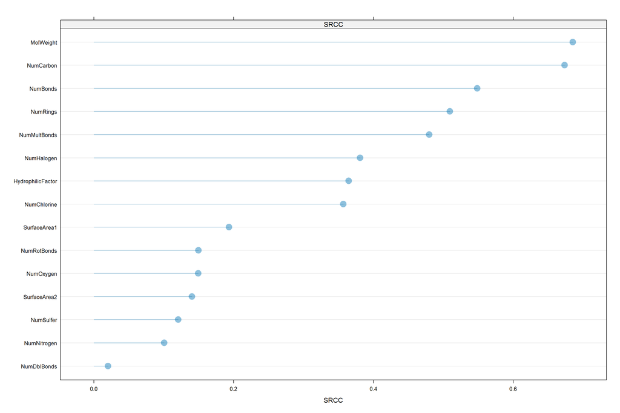

```r
##################################
# Exploring predictor performance
##################################
dotplot(Predictor ~ SRCC | Metric,
        SRCC_Summary,
        origin = 0,
        type = c("p", "h"),
        pch = 16,
        cex = 2,
        alpha = 0.45,
        prepanel = function(x, y) {
            list(ylim = levels(reorder(y, x)))
        },
        panel = function(x, y, ...) {
            panel.dotplot(x, reorder(y, x), ...)
        })
```

### 1.5.4 Maximal Information Coefficient (MIC)

[Maximal Information Coefficient](https://www.science.org/doi/10.1126/science.1205438) is an information theory-based measure of two-variable dependence through the computation of the mutual information normalized by the minimum joint entropy. It evaluates the strength of linear or non-linear association using binning as a means to apply mutual information between continuous random variables and selecting the maximum over many possible grids. The presence of high coefficient values indicate the univariate association between the numeric predictors and the numeric response.  
**[A]** The maximal information coefficient was obtained using the **minerva** package. High raw values of the metric indicate that the numeric predictors were associated with the numeric response.  
**[B]** The numeric predictors which demonstrated the best feature importance in terms of this metric are as follows:  
**[B.1]** MolWeight = 0.46793  
**[B.2]** NumCarbon = 0.44341  
**[B.3]** NumBonds = 0.32687  
**[B.4]** HydrophilicFactor = 0.32085  
**[B.5]** NumRings = 0.31618

**Code Chunk | Output**

```r
##################################
# Obtaining the maximal information coefficient
##################################
MIC <- mine(x = PMA_PreModelling_Train_Numeric[, 2:ncol(PMA_PreModelling_Train_Numeric)],
            y = PMA_PreModelling_Train_Numeric$Log_Solubility)$MIC

##################################
# Formulating the summary table
##################################
MIC_Summary <- data.frame(Predictor = names(PMA_PreModelling_Train_Numeric)[2:ncol(PMA_PreModelling_Train_Numeric)],
                          MIC = MIC[,1],
                          Metric = rep("MIC", length(MIC)))

MIC_Summary
```

```
##            Predictor       MIC Metric
## 1          MolWeight 0.4679277    MIC
## 2           NumBonds 0.3268683    MIC
## 3       NumMultBonds 0.2792600    MIC
## 4        NumRotBonds 0.1754215    MIC
## 5        NumDblBonds 0.1688472    MIC
## 6          NumCarbon 0.4434121    MIC
## 7        NumNitrogen 0.1535738    MIC
## 8          NumOxygen 0.1527421    MIC
## 9          NumSulfer 0.1297052    MIC
## 10       NumChlorine 0.2011708    MIC
## 11        NumHalogen 0.2017841    MIC
## 12          NumRings 0.3161828    MIC
## 13 HydrophilicFactor 0.3208456    MIC
## 14      SurfaceArea1 0.2054896    MIC
## 15      SurfaceArea2 0.2274047    MIC
```

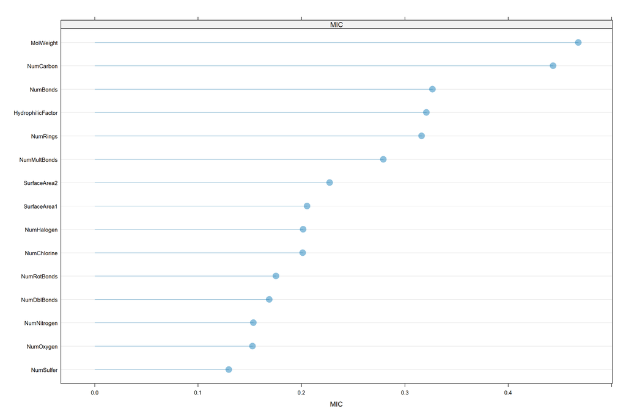

```r
##################################
# Exploring predictor performance
##################################
dotplot(Predictor ~ MIC | Metric,
        MIC_Summary,
        origin = 0,
        type = c("p", "h"),
        pch = 16,
        cex = 2,
        alpha = 0.45,
        prepanel = function(x, y) {
            list(ylim = levels(reorder(y, x)))
        },
        panel = function(x, y, ...) {
            panel.dotplot(x, reorder(y, x), ...)
        })
```

### 1.5.5 Relief Values (RV)

[Relief Values](https://link.springer.com/article/10.1023/A:1025667309714) are heuristic measures which estimate the quality of variables according to how well their values compare to instances that are near to each other, but are efficient in detecting contextual information even with strong dependencies between attributes. Random instances and the corresponding K-nearest instances are selected, with the the weights for the different prediction values, different attributes and different prediction consolidated. The rank of the instance in a sequence of instances ordered by the distance is taken into account based on a a user-defined parameter controlling the influence of the distance. The contributions of each K-nearest instances are normalized by dividing the results with the sum of all K contributions. The presence of high relief values indicate the univariate association between the numeric predictors and the numeric response.  
**[A]** The relief values statistic was obtained using the **CORElearn** package. High raw values of the metric indicate that the numeric predictors were associated with the numeric response.  
**[B]** The numeric predictors which demonstrated the best feature importance in terms of this metric are as follows:  
**[B.1]** NumNitrogen = 0.11583  
**[B.2]** NumOxygen = 0.10808  
**[B.3]** MolWeight = 0.10335  
**[B.4]** NumMultBonds = 0.06807  
**[B.5]** SurfaceArea2 = 0.06623

**Code Chunk | Output**

```r
##################################
# Obtaining the relief values
##################################
RV <- attrEval(Log_Solubility ~ .,
               data = PMA_PreModelling_Train_Numeric,
               estimator = "RReliefFequalK")

##################################
# Formulating the summary table
##################################
RV_Summary <- data.frame(Predictor = names(RV),
                         RV = RV,
                         Metric = rep("RV", length(RV)))

RV_Summary
```

```
##                           Predictor         RV Metric
## MolWeight                 MolWeight 0.10334945     RV
## NumBonds                   NumBonds 0.03989134     RV
## NumMultBonds           NumMultBonds 0.06807077     RV
## NumRotBonds             NumRotBonds 0.06121663     RV
## NumDblBonds             NumDblBonds 0.02974081     RV
## NumCarbon                 NumCarbon 0.06435924     RV
## NumNitrogen             NumNitrogen 0.11583417     RV
## NumOxygen                 NumOxygen 0.10808031     RV
## NumSulfer                 NumSulfer 0.05065068     RV
## NumChlorine             NumChlorine 0.02781883     RV
## NumHalogen               NumHalogen 0.06144457     RV
## NumRings                   NumRings 0.05518173     RV
## HydrophilicFactor HydrophilicFactor 0.04195617     RV
## SurfaceArea1           SurfaceArea1 0.05366733     RV
## SurfaceArea2           SurfaceArea2 0.06623467     RV
```

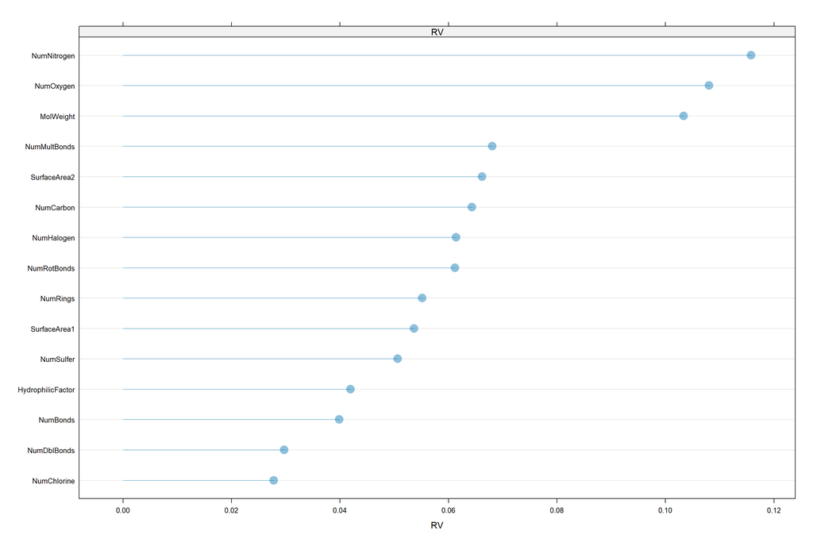

```r
##################################
# Exploring predictor performance
##################################
dotplot(Predictor ~ RV | Metric,
        RV_Summary,
        origin = 0,
        type = c("p", "h"),
        pch = 16,
        cex = 2,
        alpha = 0.45,
        prepanel = function(x, y) {
            list(ylim = levels(reorder(y, x)))
        },
        panel = function(x, y, ...) {
            panel.dotplot(x, reorder(y, x), ...)
        })
```

### 1.5.6 Volcano Plot - T-Test (VP_T)

[T-Test P-Values](https://www.jstor.org/stable/2685564?seq=1#page_scan_tab_contents) define the probability of obtaining an effect during hypothesis testing, at least as large as the one actually observed in the sample data, specifically assuming that the null hypothesis is true. The test of hypothesis involved applying T-Test to evaluate for any significant differences in the means of the numeric response between two categorical predictors. The presence of low T-Test p-values indicate the univariate discrimination of the categorical predictors in terms of the numeric response.  
**[A]** The volcano plot - t-Test p-value was obtained using the **stats** package. High raw values of the negative logarithm of the metric, and the absolute difference between group means indicate that the factor predictors were associated with the numeric response.  
**[B]** The factor predictors which demonstrated the best feature importance in terms of the negative logarithm of the t-Test p-value are as follows:  
**[B.1]** FP076 = 56.66337  
**[B.2]** FP089 = 41.12150  
**[B.3]** FP065 = 38.13254  
**[B.4]** FP168 = 33.20049  
**[B.5]** FP079 = 31.58345  
**[C]** The factor predictors which demonstrated the best feature importance in terms of the absolute difference between group means are as follows:  
**[C.1]** FP044 = 4.10986  
**[C.2]** FP193 = 3.11773  
**[C.3]** FP184 = 2.67768  
**[C.4]** FP149 = 2.64671  
**[C.5]** FP172 = 2.46454

**Code Chunk | Output**

```r
##################################
# Filtering in the factor predictors
# with the numeric response variable
##################################
PMA_PreModelling_Train_Factor <- PMA_PreModelling_Train[,grepl("FP", names(PMA_PreModelling_Train))]
PMA_PreModelling_Train_Factor$Log_Solubility <- PMA_PreModelling_Train$Log_Solubility
dim(PMA_PreModelling_Train_Factor)
```

```
## [1] 951 206
```

```r
str(PMA_PreModelling_Train_Factor)
```

```
## 'data.frame':    951 obs. of  206 variables:
##  $ FP001         : Factor w/ 2 levels "0","1": 1 1 2 1 1 2 1 2 2 2 ...
##  $ FP002         : Factor w/ 2 levels "0","1": 2 2 2 1 1 1 2 1 1 2 ...
##  $ FP003         : Factor w/ 2 levels "0","1": 1 1 2 2 2 2 1 2 2 2 ...
##  $ FP004         : Factor w/ 2 levels "0","1": 1 2 2 1 2 2 2 2 2 2 ...
##  $ FP005         : Factor w/ 2 levels "0","1": 2 2 2 1 2 1 2 1 1 2 ...
##  $ FP006         : Factor w/ 2 levels "0","1": 1 2 1 1 2 1 1 1 2 2 ...
##  $ FP007         : Factor w/ 2 levels "0","1": 1 2 1 2 1 1 1 2 2 2 ...
##  $ FP008         : Factor w/ 2 levels "0","1": 2 2 2 1 1 1 2 1 1 1 ...
##  $ FP009         : Factor w/ 2 levels "0","1": 1 1 1 1 2 2 2 1 2 1 ...
##  $ FP010         : Factor w/ 2 levels "0","1": 1 1 2 1 1 1 1 1 1 1 ...
##  $ FP011         : Factor w/ 2 levels "0","1": 1 2 1 1 1 1 1 1 2 1 ...
##  $ FP012         : Factor w/ 2 levels "0","1": 1 1 1 1 1 2 1 2 1 1 ...
##  $ FP013         : Factor w/ 2 levels "0","1": 1 1 1 1 2 1 2 1 1 1 ...
##  $ FP014         : Factor w/ 2 levels "0","1": 1 1 1 1 1 1 2 1 1 1 ...
```

[output cut: 86 more lines]

```r
summary(PMA_PreModelling_Train_Factor)
```

```
##  FP001   FP002   FP003   FP004   FP005   FP006   FP007   FP008   FP009
##  0:482   0:438   0:536   0:395   0:400   0:570   0:605   0:641   0:685
##  1:469   1:513   1:415   1:556   1:551   1:381   1:346   1:310   1:266
##
##
##
##
##  FP010   FP011   FP012   FP013   FP014   FP015   FP016   FP017   FP018
##  0:781   0:747   0:783   0:793   0:798   0:133   0:812   0:814   0:826
##  1:170   1:204   1:168   1:158   1:153   1:818   1:139   1:137   1:125
##
##
##
##
##  FP019   FP020   FP021   FP022   FP023   FP024   FP025   FP026   FP027
##  0:835   0:837   0:836   0:852   0:834   0:844   0:841   0:871   0:858
##  1:116   1:114   1:115   1: 99   1:117   1:107   1:110   1: 80   1: 93
##
##
##
##
##  FP028   FP029   FP030   FP031   FP032   FP033   FP034   FP035   FP036
##  0:850   0:854   0:862   0:866   0:881   0:885   0:875   0:882   0:879
##  1:101   1: 97   1: 89   1: 85   1: 70   1: 66   1: 76   1: 69   1: 72
##
##
##
##
##  FP037   FP038   FP039   FP040   FP041   FP042   FP043   FP044   FP045
##  0:884   0:869   0:880   0:886   0:891   0:897   0:888   0:894   0:898
##  1: 67   1: 82   1: 71   1: 65   1: 60   1: 54   1: 63   1: 57   1: 53
##
##
##
##
##  FP046   FP047   FP048   FP049   FP050   FP051   FP052   FP053   FP054
##  0:651   0:698   0:833   0:835   0:844   0:847   0:864   0:862   0:879
##  1:300   1:253   1:118   1:116   1:107   1:104   1: 87   1: 89   1: 72
##
##
```

[output cut: 106 more lines]

```
##
##  FP191   FP192   FP193   FP194   FP195   FP196   FP197   FP198   FP201
##  0:884   0:893   0:892   0:895   0:893   0:897   0:901   0:897   0:901
##  1: 67   1: 58   1: 59   1: 56   1: 58   1: 54   1: 50   1: 54   1: 50
##
##
##
##
##  FP202   FP203   FP204   FP205   FP206   FP207   FP208   Log_Solubility
##  0:706   0:842   0:857   0:877   0:894   0:897   0:844   Min.   :-11.620
##  1:245   1:109   1: 94   1: 74   1: 57   1: 54   1:107   1st Qu.: -3.955
##                                                          Median : -2.510
##                                                          Mean   : -2.719
##                                                          3rd Qu.: -1.360
##                                                          Max.   :  1.580
```

```r
##################################
# Obtaining the t-test statistics
##################################
VP_T <- apply(PMA_PreModelling_Train_Factor[, 1:(ncol(PMA_PreModelling_Train_Factor)-1)],
              2,
              function(x, y){
                tStats <- t.test(y ~ x)[c("statistic", "p.value", "estimate")]
                unlist(tStats)},
              y=PMA_PreModelling_Train_Factor$Log_Solubility)

##################################
# Formulating the summary table
##################################
VP_T_Summary <- as.data.frame(t(VP_T))
names(VP_T_Summary) <- c("t.Statistic", "t.Test_P.Value", "Mean0", "Mean1")
VP_T_Summary$MeanDifference <- VP_T_Summary$Mean1 - VP_T_Summary$Mean0
VP_T_Summary$Predictor <- names(PMA_PreModelling_Train_Factor[,-ncol(PMA_PreModelling_Train_Factor)])
VP_T_Summary$Metric <- rep("VP_T", nrow(VP_T_Summary))
VP_T_Summary$NegativeLog10_t.Test_P.Value <- -log10(VP_T_Summary$t.Test_P.Value)
VP_T_Summary$AbsoluteMeanDifference <- abs(VP_T_Summary$Mean1 - VP_T_Summary$Mean0)

VP_T_Summary$Group <- ifelse(rownames(VP_T_Summary)=="FP076","FP076",
                             ifelse(rownames(VP_T_Summary)=="FP089","FP089",
                                    ifelse(rownames(VP_T_Summary)=="FP065","FP065",
                                           ifelse(rownames(VP_T_Summary)=="FP044","FP044",
                                                  ifelse(rownames(VP_T_Summary)=="FP193","FP193",
                                                         "Others")))))

VP_T_Summary
```

```
##       t.Statistic t.Test_P.Value     Mean0     Mean1 MeanDifference Predictor
## FP001 -4.02204024   6.287404e-05 -2.978465 -2.451471    0.526993515     FP001
## FP002 10.28672686   1.351580e-23 -2.021347 -3.313860   -1.292512617     FP002
## FP003 -2.03644225   4.198619e-02 -2.832164 -2.571855    0.260308757     FP003
## FP004 -4.94895770   9.551772e-07 -3.128380 -2.427428    0.700951689     FP004
## FP005 10.28247538   1.576549e-23 -1.969000 -3.262722   -1.293722323     FP005
## FP006 -7.87583806   9.287835e-15 -3.109421 -2.133832    0.975589032     FP006
## FP007 -0.88733923   3.751398e-01 -2.759967 -2.646185    0.113781971     FP007
## FP008  3.32843788   9.119521e-04 -2.582652 -2.999613   -0.416960797     FP008
## FP009 11.49360533   7.467714e-27 -2.249591 -3.926278   -1.676686955     FP009
## FP010 -4.11392307   4.973603e-05 -2.824302 -2.232824    0.591478647     FP010
## FP011 -7.01680213   1.067782e-11 -2.934645 -1.927353    1.007292306     FP011
## FP012 -1.89255407   5.953582e-02 -2.773755 -2.461369    0.312385742     FP012
## FP013 11.73267872   1.088092e-24 -2.365485 -4.490696   -2.125210704     FP013
## FP014 11.47456176   1.157457e-23 -2.375401 -4.508431   -2.133030370     FP014
## FP015 -7.73718733   1.432769e-12 -4.404286 -2.444487    1.959799162     FP015
## FP016 -0.61719794   5.377695e-01 -2.733559 -2.631007    0.102551919     FP016
## FP017  2.73915987   6.681864e-03 -2.654607 -3.098613   -0.444006259     FP017
## FP018  4.26743510   2.806561e-05 -2.643402 -3.215280   -0.571878063     FP018
## FP019 -2.31045847   2.207143e-02 -2.766910 -2.370603    0.396306731     FP019
## FP020 -3.44119896   7.251032e-04 -2.785806 -2.224912    0.560894171     FP020
## FP021  3.35165112   1.009498e-03 -2.642392 -3.272348   -0.629955482     FP021
## FP022 -0.66772403   5.051252e-01 -2.728040 -2.637071    0.090969199     FP022
## FP023  2.18958532   2.989162e-02 -2.673106 -3.042650   -0.369544057     FP023
## FP024 -2.43189276   1.617811e-02 -2.766457 -2.340841    0.425616224     FP024
## FP025 -2.68651403   7.981132e-03 -2.771677 -2.312545    0.459131121     FP025
## FP026  0.58596455   5.591541e-01 -2.709082 -2.821875   -0.112793485     FP026
## FP027 -4.46177875   1.714807e-05 -2.793800 -2.024516    0.769283405     FP027
## FP028 -3.36478123   1.011310e-03 -2.791941 -2.101089    0.690852068     FP028
## FP029  1.50309317   1.346711e-01 -2.696475 -2.913093   -0.216617374     FP029
## FP030 -4.18564626   5.684141e-05 -2.799582 -1.933933    0.865649782     FP030
## FP031 -0.19030898   8.494207e-01 -2.721986 -2.683765    0.038221437     FP031
## FP032 -2.86824205   5.100440e-03 -2.757832 -2.224429    0.533403438     FP032
## FP033 -2.48343886   1.492327e-02 -2.751062 -2.282879    0.468183359     FP033
## FP034  0.81786492   4.147985e-01 -2.709737 -2.820263   -0.110526015     FP034
## FP035  4.17698556   6.851675e-05 -2.659660 -3.471594   -0.811934339     FP035
## FP036 -5.31186085   6.344823e-07 -2.787224 -1.880417    0.906807452     FP036
## FP037  1.37213471   1.734895e-01 -2.700271 -2.960000   -0.259728507     FP037
## FP038 -2.55044552   1.224045e-02 -2.764833 -2.228293    0.536540459     FP038
## FP039  6.83856010   1.396591e-09 -2.588330 -4.332817   -1.744487356     FP039
```

[output cut: 357 more lines]

```
## FP192   VP_T                  0.234063851            0.117932965 Others
## FP193   VP_T                 15.796986918            3.117735616  FP193
## FP194   VP_T                  0.516031959            0.175701915 Others
## FP195   VP_T                  6.984892592            1.113736340 Others
## FP196   VP_T                  7.896470322            1.187762913 Others
## FP197   VP_T                  3.499343085            0.913245061 Others
## FP198   VP_T                  3.585288501            1.014313143 Others
## FP201   VP_T                  3.677604573            0.738813984 Others
## FP202   VP_T                  8.215933727            0.860174019 Others
## FP203   VP_T                  0.559143393            0.200564841 Others
## FP204   VP_T                  2.312609803            0.469543435 Others
## FP205   VP_T                  6.604060360            1.452273414 Others
## FP206   VP_T                  3.210209626            0.734954669 Others
## FP207   VP_T                 10.937926026            2.173553202 Others
## FP208   VP_T                  0.768988609            0.251819108 Others
```

```r
##################################
# Selecting the best-performing
# predictors based from metrics
##################################
VP_T_Summary_Top15_TTestPValue <- VP_T_Summary[order(VP_T_Summary$NegativeLog10_t.Test_P.Value,decreasing=TRUE),]
(VP_T_Summary_Top15_TTestPValue <- VP_T_Summary_Top15_TTestPValue[1:15,])
```

```
##       t.Statistic t.Test_P.Value     Mean0     Mean1 MeanDifference Predictor
## FP076    18.19671   2.170836e-57 -1.949953 -4.292756      -2.342803     FP076
## FP089    15.68685   7.559612e-42 -2.131606 -4.506936      -2.375330     FP089
## FP065    13.67947   7.369864e-39 -1.740827 -3.389468      -1.648641     FP065
## FP168    12.78784   6.302482e-34 -1.659686 -3.250521      -1.590836     FP168
## FP079    12.46647   2.609452e-32 -1.649763 -3.199207      -1.549445     FP079
## FP082    12.55490   3.329065e-32 -1.573824 -3.177143      -1.603319     FP082
## FP112    13.31169   4.090297e-31 -2.293512 -4.478541      -2.185029     FP112
## FP092    12.71462   9.160201e-31 -2.250250 -4.169957      -1.919707     FP092
## FP172    13.04071   8.112523e-28 -2.345390 -4.809931      -2.464540     FP172
## FP164    11.15556   6.131703e-27 -1.830706 -3.245042      -1.414336     FP164
## FP070    11.33501   6.532630e-27 -2.155840 -3.739142      -1.583302     FP070
## FP009    11.49361   7.467714e-27 -2.249591 -3.926278      -1.676687     FP009
## FP087    11.07193   5.850147e-26 -1.684808 -3.107540      -1.422732     FP087
## FP013    11.73268   1.088092e-24 -2.365485 -4.490696      -2.125211     FP013
## FP014    11.47456   1.157457e-23 -2.375401 -4.508431      -2.133030     FP014
##       Metric NegativeLog10_t.Test_P.Value AbsoluteMeanDifference  Group
## FP076   VP_T                     56.66337               2.342803  FP076
## FP089   VP_T                     41.12150               2.375330  FP089
## FP065   VP_T                     38.13254               1.648641  FP065
## FP168   VP_T                     33.20049               1.590836 Others
## FP079   VP_T                     31.58345               1.549445 Others
## FP082   VP_T                     31.47768               1.603319 Others
## FP112   VP_T                     30.38825               2.185029 Others
## FP092   VP_T                     30.03810               1.919707 Others
## FP172   VP_T                     27.09084               2.464540 Others
## FP164   VP_T                     26.21242               1.414336 Others
## FP070   VP_T                     26.18491               1.583302 Others
## FP009   VP_T                     26.12681               1.676687 Others
## FP087   VP_T                     25.23283               1.422732 Others
## FP013   VP_T                     23.96333               2.125211 Others
## FP014   VP_T                     22.93650               2.133030 Others
```

```r
VP_T_Summary_Top15_AbsoluteMeanDifference <- VP_T_Summary[order(VP_T_Summary$AbsoluteMeanDifference,decreasing=TRUE),]
(VP_T_Summary_Top15_AbsoluteMeanDifference <- VP_T_Summary_Top15_AbsoluteMeanDifference[1:15,])
```

```
##       t.Statistic t.Test_P.Value     Mean0     Mean1 MeanDifference Predictor
## FP044   15.198443   1.458342e-22 -2.472237 -6.582105      -4.109868     FP044
## FP193   11.061736   1.595927e-16 -2.525146 -5.642881      -3.117736     FP193
## FP184   10.249790   9.572172e-17 -2.493318 -5.171000      -2.677682     FP184
## FP149    9.674980   8.530838e-16 -2.479225 -5.125930      -2.646705     FP149
## FP172   13.040707   8.112523e-28 -2.345390 -4.809931      -2.464540     FP172
## FP089   15.686846   7.559612e-42 -2.131606 -4.506936      -2.375330     FP089
## FP076   18.196710   2.170836e-57 -1.949953 -4.292756      -2.342803     FP076
## FP112   13.311694   4.090297e-31 -2.293512 -4.478541      -2.185029     FP112
## FP207    8.348946   1.153650e-11 -2.595151 -4.768704      -2.173553     FP207
## FP014   11.474562   1.157457e-23 -2.375401 -4.508431      -2.133030     FP014
## FP013   11.732679   1.088092e-24 -2.365485 -4.490696      -2.125211     FP013
## FP190    8.237965   2.799252e-12 -2.574785 -4.556522      -1.981737     FP190
## FP015   -7.737187   1.432769e-12 -4.404286 -2.444487       1.959799     FP015
## FP092   12.714617   9.160201e-31 -2.250250 -4.169957      -1.919707     FP092
## FP169   10.798406   1.952902e-22 -2.370413 -4.241017      -1.870604     FP169
##       Metric NegativeLog10_t.Test_P.Value AbsoluteMeanDifference  Group
## FP044   VP_T                     21.83614               4.109868  FP044
## FP193   VP_T                     15.79699               3.117736  FP193
## FP184   VP_T                     16.01899               2.677682 Others
## FP149   VP_T                     15.06901               2.646705 Others
## FP172   VP_T                     27.09084               2.464540 Others
## FP089   VP_T                     41.12150               2.375330  FP089
## FP076   VP_T                     56.66337               2.342803  FP076
## FP112   VP_T                     30.38825               2.185029 Others
## FP207   VP_T                     10.93793               2.173553 Others
## FP014   VP_T                     22.93650               2.133030 Others
## FP013   VP_T                     23.96333               2.125211 Others
## FP190   VP_T                     11.55296               1.981737 Others
## FP015   VP_T                     11.84382               1.959799 Others
## FP092   VP_T                     30.03810               1.919707 Others
## FP169   VP_T                     21.70932               1.870604 Others
```

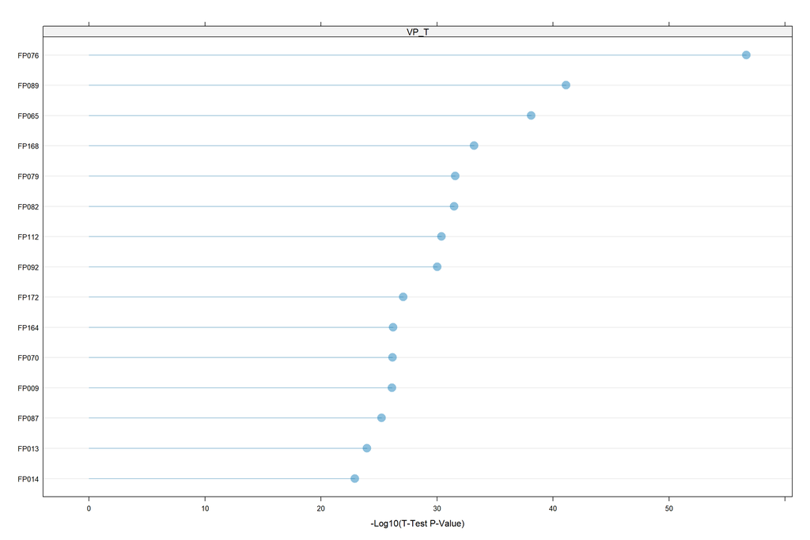

```r
##################################
# Exploring predictor performance
##################################
dotplot(Predictor ~ NegativeLog10_t.Test_P.Value | Metric,
        VP_T_Summary_Top15_TTestPValue,
        origin = 0,
        xlab = "-Log10(T-Test P-Value)",
        type = c("p", "h"),
        pch = 16,
        cex = 2,
        alpha = 0.45,
        prepanel = function(x, y) {
            list(ylim = levels(reorder(y, x)))
        },
        panel = function(x, y, ...) {
            panel.dotplot(x, reorder(y, x), ...)
        })
```

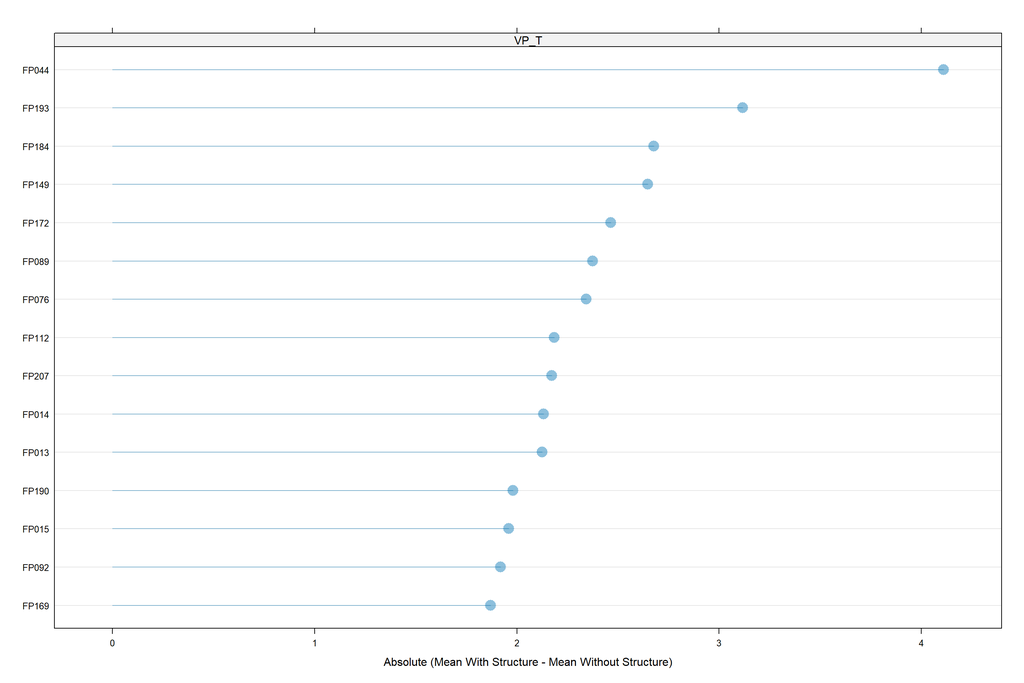

```r
dotplot(Predictor ~ AbsoluteMeanDifference | Metric,
        VP_T_Summary_Top15_AbsoluteMeanDifference,
        origin = 0,
        xlab = "Absolute (Mean With Structure - Mean Without Structure)",
        type = c("p", "h"),
        pch = 16,
        cex = 2,
        alpha = 0.45,
        prepanel = function(x, y) {
            list(ylim = levels(reorder(y, x)))
        },
        panel = function(x, y, ...) {
            panel.dotplot(x, reorder(y, x), ...)
        })
```

## 1.6 Consolidated Findings

**[A]** The model-independent feature importance for all numeric predictors were evaluated in terms of the following metrics:  
**[A.1]** **LOWESS_PR: Locally Weighted Scatterplot Smoothing Pseudo-R-Squared** (**caret** package)  
**[A.2]** **PCC: Pearson’s Correlation Coefficient** (**stats** package)  
**[A.3]** **SRCC: Spearman’s Rank Correlation Coefficient** (**stats** package)  
**[A.4]** **MIC: Maximal Information Coefficient** (**minerva** package)  
**[A.5]** **RV: Relief Values** (**CORElearn** package)  
**[B]** The numeric predictors which demonstrated the most consistent feature importance across the given metrics are as follows:  
**[B.1]** MolWeight  
**[B.2]** NumCarbon  
**[B.3]** NumMultBonds  
**[B.4]** NumHalogen  
**[B.5]** NumRings  
**[C]** The model-independent feature importance for all factor predictors were evaluated in terms of the following metrics:  
**[C.1]** **VP_T: Volcano Plot - T-Test** (**stats** package)  
**[D]** The factor predictors which demonstrated the most consistent feature importance across the given metrics are as follows:  
**[D.1]** FP076  
**[D.2]** FP044  
**[D.3]** FP089  
**[D.4]** FP193  
**[D.5]** FP065

**Code Chunk | Output**

```r
##################################
# Consolidating all performance metrics
# for the numeric predictors
##################################
NumericPredictor_Metrics <- cbind(LOWESS_PR_Summary$LOWESS_PR,
                                  PCC_Summary$PCC,
                                  SRCC_Summary$SRCC,
                                  MIC_Summary$MIC,
                                  RV_Summary$RV)

colnames(NumericPredictor_Metrics) <- c("LOWESS_PR",
                                        "PCC",
                                        "SRCC",
                                        "MIC",
                                        "RV")

rownames(NumericPredictor_Metrics) <- names(PMA_PreModelling_Train_Numeric)[2:ncol(PMA_PreModelling_Train_Numeric)]

NumericPredictor_Metrics <- as.data.frame(NumericPredictor_Metrics)

NumericPredictor_Metrics$Group <- ifelse(rownames(NumericPredictor_Metrics)=="MolWeight","MolWeight",
                                         ifelse(rownames(NumericPredictor_Metrics)=="NumCarbon","NumCarbon",
                                                ifelse(rownames(NumericPredictor_Metrics)=="NumMultBonds","NumMultBonds",
                                                       ifelse(rownames(NumericPredictor_Metrics)=="NumHalogen","NumHalogen",
                                                              ifelse(rownames(NumericPredictor_Metrics)=="NumRings","NumRings",
                                                                     "Others")))))

NumericPredictor_Metrics
```

```
##                      LOWESS_PR         PCC       SRCC       MIC         RV
## MolWeight         4.443734e-01 0.658495868 0.68529880 0.4679277 0.10334945
## NumBonds          2.093744e-01 0.457574429 0.54839850 0.3268683 0.03989134
## NumMultBonds      2.758859e-01 0.525248387 0.47971353 0.2792600 0.06807077
## NumRotBonds       2.230342e-02 0.149343282 0.14976036 0.1754215 0.06121663
## NumDblBonds       1.530295e-06 0.001237051 0.02042731 0.1688472 0.02974081
## NumCarbon         3.657997e-01 0.604813811 0.67359114 0.4434121 0.06435924
## NumNitrogen       1.045101e-02 0.102230176 0.10078218 0.1535738 0.11583417
## NumOxygen         1.710199e-02 0.130774566 0.14954994 0.1527421 0.10808031
## NumSulfer         8.357325e-03 0.091418407 0.12090249 0.1297052 0.05065068
## NumChlorine       2.540713e-01 0.504054819 0.35707519 0.2011708 0.02781883
## NumHalogen        2.541532e-01 0.504136055 0.38111965 0.2017841 0.06144457
## NumRings          2.384330e-01 0.488295986 0.50941815 0.3161828 0.05518173
## HydrophilicFactor 1.505216e-01 0.309022159 0.36469127 0.3208456 0.04195617
## SurfaceArea1      1.941711e-01 0.193769382 0.19339720 0.2054896 0.05366733
## SurfaceArea2      2.080820e-01 0.143941883 0.14057885 0.2274047 0.06623467
##                          Group
## MolWeight            MolWeight
## NumBonds                Others
## NumMultBonds      NumMultBonds
## NumRotBonds             Others
## NumDblBonds             Others
## NumCarbon            NumCarbon
## NumNitrogen             Others
## NumOxygen               Others
## NumSulfer               Others
## NumChlorine             Others
## NumHalogen          NumHalogen
## NumRings              NumRings
## HydrophilicFactor       Others
## SurfaceArea1            Others
## SurfaceArea2            Others
```

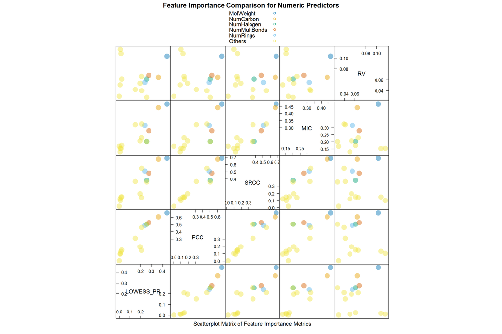

```r
splom(~NumericPredictor_Metrics[,c(1:5)],
      groups = NumericPredictor_Metrics$Group,
      pch = 16,
      cex = 2,
      alpha = 0.45,
      varnames = c("LOWESS_PR", "PCC", "SRCC", "MIC", "RV"),
      auto.key = list(points = TRUE, space = "top"),
      main = "Feature Importance Comparison for Numeric Predictors",
      xlab = "Scatterplot Matrix of Feature Importance Metrics" )
```

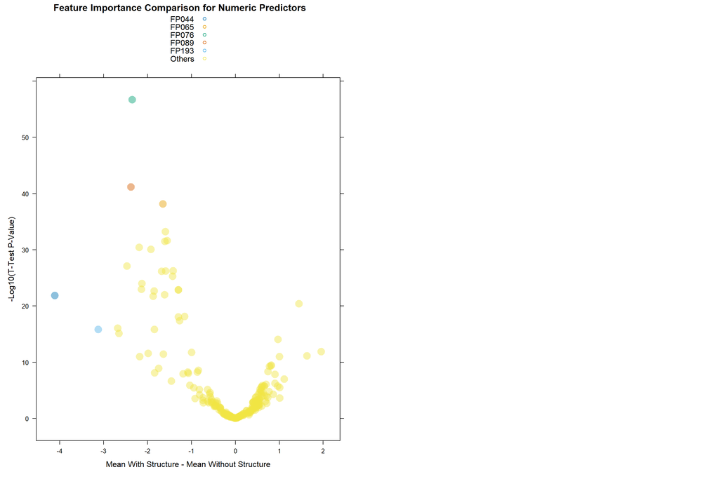

```r
##################################
# Consolidating all performance metrics
# for the factor predictors
##################################
TTEST_P.Value_Plot <- xyplot(NegativeLog10_t.Test_P.Value ~ MeanDifference,
       groups = VP_T_Summary$Group,
       data = VP_T_Summary,
       xlab = "Mean With Structure - Mean Without Structure",
       ylab = "-Log10(T-Test P-Value)",
       type = "p",
       pch = 16,
       cex = 2,
       alpha = 0.45,
       auto.key = list(points = TRUE, space = "top"),
       main = "Feature Importance Comparison for Numeric Predictors")

grid.arrange(TTEST_P.Value_Plot,
             ncol = 2)
```

# **2. Summary**

[figure not shown]

# **3. References**

**[Book]** [Applied Predictive Modeling](http://appliedpredictivemodeling.com/) by Max Kuhn and Kjell Johnson  
**[Book]** [An Introduction to Statistical Learning](https://www.statlearning.com/) by Gareth James, Daniela Witten, Trevor Hastie and Rob Tibshirani  
**[Book]** [Multivariate Data Visualization with R](http://lmdvr.r-forge.r-project.org/figures/figures.html) by Deepayan Sarkar  
**[Book]** [Machine Learning](https://bookdown.org/ssjackson300/Machine-Learning-Lecture-Notes/) by Samuel Jackson  
**[Book]** [Data Modeling Methods](https://bookdown.org/larget_jacob/data-modeling-methods/) by Jacob Larget  
**[Book]** [Introduction to R](https://biocorecrg.github.io/CRG_RIntroduction/) by Sara Bonnin  
**[R Package]** [AppliedPredictiveModeling](https://cran.r-project.org/web//packages/AppliedPredictiveModeling/AppliedPredictiveModeling.pdf) by Max Kuhn  
**[R Package]** [caret](https://topepo.github.io/caret/index.html) by Max Kuhn  
**[R Package]** [rpart](https://mran.microsoft.com/web/packages/rpart/rpart.pdf) by Terry Therneau and Beth Atkinson  
**[R Package]** [lattice](https://cran.r-project.org/web/packages/lattice/lattice.pdf) by Deepayan Sarkar  
**[R Package]** [dplyr](https://cran.r-project.org/web/packages/dplyr/index.html/) by Hadley Wickham  
**[R Package]** [moments](https://cran.r-project.org/web/packages/moments/index.html) by Lukasz Komsta and Frederick  
**[R Package]** [skimr](https://cran.r-project.org/web/packages/skimr/skimr.pdf) by Elin Waring  
**[R Package]** [RANN](https://cran.r-project.org/web/packages/RANN/RANN.pdf) by Sunil Arya, David Mount, Samuel Kemp and Gregory Jefferis  
**[R Package]** [corrplot](https://cran.r-project.org/web/packages/corrplot/corrplot.pdf) by Taiyun Wei  
**[R Package]** [tidyverse](https://cran.r-project.org/web/packages/tidyverse/tidyverse.pdf) by Hadley Wickham  
**[R Package]** [lares](https://cran.rstudio.com/web/packages/lares/lares.pdf) by Bernardo Lares  
**[R Package]** [DMwR2](https://mran.microsoft.com/snapshot/2016-05-02/web/packages/DMwR/DMwR.pdf) by Luis Torgo  
**[R Package]** [gridExtra](https://cran.r-project.org/web/packages/gridExtra/gridExtra.pdf) by Baptiste Auguie and Anton Antonov  
**[R Package]** [rattle](https://cran.r-project.org/web/packages/rattle/rattle.pdf) by Graham Williams  
**[R Package]** [rpart.plot](https://cran.r-project.org/web/packages/rpart.plot/rpart.plot.pdf) by Stephen Milborrow  
**[R Package]** [RColorBrewer](https://cran.r-project.org/web//packages/RColorBrewer/RColorBrewer.pdf) by Erich Neuwirth  
**[R Package]** [stats](https://search.r-project.org/R/refmans/stats/html/00Index.html) by R Core Team  
**[R Package]** [pls](https://cran.r-project.org/web/packages/pls/pls.pdf) by Kristian Hovde Liland  
**[R Package]** [nnet](https://cran.r-project.org/web/packages/nnet/nnet.pdf) by Brian Ripley  
**[R Package]** [elasticnet](https://cran.r-project.org/web/packages/elasticnet/elasticnet.pdf) by Hui Zou  
**[R Package]** [earth](https://cran.r-project.org/web/packages/earth/earth.pdf) by Stephen Milborrow  
**[R Package]** [party](https://cran.r-project.org/web/packages/party/party.pdf) by Torsten Hothorn  
**[R Package]** [kernlab](https://cran.r-project.org/web/packages/kernlab/kernlab.pdf) by Alexandros Karatzoglou  
**[R Package]** [randomForest](https://cran.r-project.org/web/packages/randomForest/randomForest.pdf) by Andy Liaw  
**[R Package]** [Cubist](https://cran.r-project.org/web/packages/Cubist/Cubist.pdf) by Max Kuhn  
**[R Package]** [minerva](https://cran.r-project.org/web/packages/minerva/minerva.pdf) by Michele Filosi  
**[R Package]** [CORElearn](https://cran.r-project.org/web/packages/CORElearn/CORElearn.pdf) by Marko Robnik-Sikonja and Petr Savicky  
**[Article]** [The caret Package](https://topepo.github.io/caret/index.html) by Max Kuhn  
**[Article]** [A Short Introduction to the caret Package](https://cran.r-project.org/web/packages/caret/vignettes/caret.html) by Max Kuhn  
**[Article]** Caret Package – A Practical Guide to Machine Learning in R by Selva Prabhakaran  
**[Article]** [Tuning Machine Learning Models Using the Caret R Package](https://machinelearningmastery.com/tuning-machine-learning-models-using-the-caret-r-package/) by Jason Brownlee  
**[Article]** [Lattice Graphs](http://www.sthda.com/english/wiki/lattice-graphs) by STHDA Team  
**[Article]** [A Tour of Machine Learning Algorithms](https://machinelearningmastery.com/a-tour-of-machine-learning-algorithms/) by Jason Brownlee  
**[Article]** [Correlation in R: Pearson and Spearman Correlation Matrix](https://www.guru99.com/r-pearson-spearman-correlation.html) by Daniel Johnson  
**[Article]** [Correlation (Pearson, Kendall, Spearman)](https://www.statisticssolutions.com/free-resources/directory-of-statistical-analyses/correlation-pearson-kendall-spearman/) by Statistics Solutions Team  
**[Article]** A Comparison of the Pearson and Spearman Correlation Methods by Minitab Support Team  
**[Article]** [How to Perform Lowess Smoothing in R (Step-by-Step)](https://www.statology.org/lowess-smoothing-r/) by Statology Team  
**[Article]** [Maximal Information Coefficient](https://www.r-bloggers.com/2014/09/maximal-information-coefficient-part-ii/) by R Bloggers Team  
**[Article]** [Visualization of Volcano Plots in R](https://sdgamboa.github.io/post/2020_volcano/) by Samuel David Gamboa-Tuz  
**[Article]** [Using Volcano Plots in R to Visualize Microarray and RNA-seq Results](https://www.r-bloggers.com/2014/05/using-volcano-plots-in-r-to-visualize-microarray-and-rna-seq-results/) by Stephen Turner  
**[Publication]** [Robust Locally Weighted Regression and Smoothing Scatterplots](https://www.tandfonline.com/doi/abs/10.1080/01621459.1979.10481038) by William Cleveland (Journal of the American Statistical Association)  
**[Publication]** [Mathematical Contributions to the Theory of Evolution: Regression, Heredity and Panmixia](https://royalsocietypublishing.org/doi/10.1098/rsta.1896.0007) by Karl Pearson (Royal Society)  
**[Publication]** [The Proof and Measurement of Association between Two Things](https://www.jstor.org/stable/1412159?origin=crossref) by Charles Spearman (The American Journal of Psychology)  
**[Publication]** [Detecting Novel Associations in Large Data Sets](https://www.science.org/doi/10.1126/science.1205438) by David Reshef, Yakir Reshef, Hilary Finucane, Sharon Grossman, Gilean Mcvean, Peter Turnbaugh, Eric Lander, Michael Mitzenmacher and Pardis Sabeti (Science)  
**[Publication]** [Theoretical and Empirical Analysis of ReliefF and RReliefF](https://link.springer.com/article/10.1023/A:1025667309714) by Marko Robnik-Šikonja and Igor Kononenko (Machine Learning)  
**[Publication]** [First (?) Occurrence of Common Terms in Probability and Statistics-A Second List, with Corrections](https://www.jstor.org/stable/2685564?seq=1#page_scan_tab_contents) by H David (The American Statistician)  
**[Course]** [Applied Data Mining and Statistical Learning](https://online.stat.psu.edu/stat508/) by Penn State Eberly College of Science  
**[Course]** [Regression Methods](https://online.stat.psu.edu/stat501/) by Penn State Eberly College of Science  
**[Course]** [Applied Regression Analysis](https://online.stat.psu.edu/stat462/) by Penn State Eberly College of Science